# BIB Revision — Supplementary Analysis

Herdiantri Sufriyana, Yu-Wei Wu, Emily Chia-Yu Su

2026-06-24

# LOPE — Mid-secretory endometrium (Fig 3A, cx)

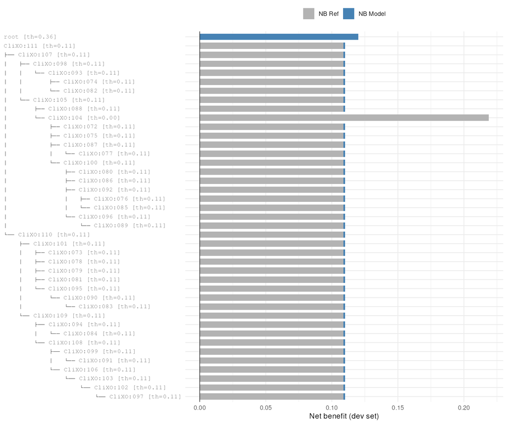

**Figure 1.** Net benefit of model vs. reference at selected thresholds — LOPE — Mid-secretory endometrium (Fig 3A, cx).

Table 2. Confusion matrices — LOPE — Mid-secretory endometrium (Fig 3A, cx).

| Ontology | PPV/TPR (Dev) | PPV/TPR (Test) | NPV/TNR (Dev) | NPV/TNR (Test) | C1 | C2 | C3 | C4 | Reported |
| --- | --- | --- | --- | --- | --- | --- | --- | --- | --- |
| root (ICA1, PLIN2, BMP2, DOCK8, GDA, NFIL3, RDX, CCDC127, CORO2A, BCAR3, SPAG4, FAM172A, ANKRD37, PKM, CLIP1, TUBB4B, AZIN1, ANKRD13A, PDE5A, IGF1, TUFT1, KRT19, INPP5F, EFNB1, SMPDL3A, PTPRD, NPR3, P… | 58.1% (53.4, 62.8) / 100.0% (100.0, 100.0) | 2.8% (2.3, 3.2) / 100.0% (100.0, 100.0) | 100.0% (100.0, 100.0) / 80.8% (77.5, 84.0) | — / 0.0% (0.0, 0.0) | ✓\| | \| |  |  |  |
| CliXO:111 (ICA1, PLIN2, BMP2, DOCK8, GDA, NFIL3, RDX, CCDC127, CORO2A, BCAR3, SPAG4, FAM172A, ANKRD37, PKM, CLIP1, TUBB4B, AZIN1, ANKRD13A, PDE5A, IGF1, TUFT1, KRT19, INPP5F, EFNB1, SMPDL3A, PTPRD, NP… | 20.6% (18.2, 23.1) / 100.0% (100.0, 100.0) | 2.8% (2.3, 3.2) / 100.0% (100.0, 100.0) | — / 0.0% (0.0, 0.0) | — / 0.0% (0.0, 0.0) | ✓\| | ✓\| | ✓ |  | CliXO:111 |
| ├── CliXO:107 (BMP2, DOCK8, RDX, FAM172A, PKM, TUBB4B, AZIN1, PDE5A, IGF1, INPP5F, EFNB1, SMPDL3A, PTPRD, P2RY14, SH3PXD2A, CDO1, LDLR, ASAH1, MRPL34, ZNF555, ELOVL5, APOLD1, FAM43A, BBS4, MCAT, DYNLL… | 20.6% (18.2, 23.1) / 100.0% (100.0, 100.0) | 2.8% (2.3, 3.2) / 100.0% (100.0, 100.0) | — / 0.0% (0.0, 0.0) | — / 0.0% (0.0, 0.0) | ✓\| | ✓\| |  |  | CliXO:111 |
| │ ├── CliXO:098 (DOCK8, RDX, AZIN1, PDE5A, IGF1, SMPDL3A, PTPRD, ASAH1, FAM43A, FAP, DDIT4, P4HA1, ERRFI1) | 20.6% (18.2, 23.1) / 100.0% (100.0, 100.0) | 2.8% (2.3, 3.2) / 100.0% (100.0, 100.0) | — / 0.0% (0.0, 0.0) | — / 0.0% (0.0, 0.0) | ✓\| | ✓\| |  |  |  |
| │ │ └── CliXO:093 (DOCK8, RDX, AZIN1, PDE5A, IGF1, FAP, DDIT4, P4HA1, ERRFI1) | 20.6% (18.2, 23.1) / 100.0% (100.0, 100.0) | 2.8% (2.3, 3.2) / 100.0% (100.0, 100.0) | — / 0.0% (0.0, 0.0) | — / 0.0% (0.0, 0.0) | ✓\| | ✓\| |  |  |  |
| │ │ ├── CliXO:074 (RDX, AZIN1) | 20.6% (18.2, 23.1) / 100.0% (100.0, 100.0) | 2.8% (2.3, 3.2) / 100.0% (100.0, 100.0) | — / 0.0% (0.0, 0.0) | — / 0.0% (0.0, 0.0) | ✓\| | ✓\| |  |  |  |
| │ │ └── CliXO:082 (RDX, P4HA1) | 20.6% (18.2, 23.1) / 100.0% (100.0, 100.0) | 2.8% (2.3, 3.2) / 100.0% (100.0, 100.0) | — / 0.0% (0.0, 0.0) | — / 0.0% (0.0, 0.0) | ✓\| | ✓\| |  |  |  |
| │ └── CliXO:105 (BMP2, RDX, FAM172A, PKM, TUBB4B, AZIN1, PDE5A, IGF1, INPP5F, EFNB1, PTPRD, P2RY14, SH3PXD2A, CDO1, MRPL34, ELOVL5, APOLD1, FAM43A, BBS4, MCAT, DYNLL1, SLCO2A1, SYDE1, HYAL2, FAP, APLN… | 20.6% (18.2, 23.1) / 100.0% (100.0, 100.0) | 2.8% (2.3, 3.2) / 100.0% (100.0, 100.0) | — / 0.0% (0.0, 0.0) | — / 0.0% (0.0, 0.0) | ✓\| | ✓\| |  |  | CliXO:111 |
| │ ├── CliXO:088 (PDE5A, INPP5F, PTPRD, CDO1, APOLD1) | 20.6% (18.2, 23.1) / 100.0% (100.0, 100.0) | 2.8% (2.3, 3.2) / 100.0% (100.0, 100.0) | — / 0.0% (0.0, 0.0) | — / 0.0% (0.0, 0.0) | ✓\| | ✓\| |  |  |  |
| │ └── CliXO:104 (BMP2, RDX, FAM172A, PKM, TUBB4B, AZIN1, PDE5A, IGF1, INPP5F, EFNB1, PTPRD, P2RY14, SH3PXD2A, CDO1, MRPL34, ELOVL5, FAM43A, BBS4, MCAT, DYNLL1, SLCO2A1, SYDE1, HYAL2, FAP, APLN, TRIM68… | 20.6% (18.2, 23.1) / 100.0% (100.0, 100.0) | 2.8% (2.3, 3.2) / 100.0% (100.0, 100.0) | — / 0.0% (0.0, 0.0) | — / 0.0% (0.0, 0.0) | ✓\| | ✓\| |  |  |  |
| │ ├── CliXO:072 (SLCO2A1, TRIM68) | 20.6% (18.2, 23.1) / 100.0% (100.0, 100.0) | 2.8% (2.3, 3.2) / 100.0% (100.0, 100.0) | — / 0.0% (0.0, 0.0) | — / 0.0% (0.0, 0.0) | ✓\| | ✓\| |  |  |  |
| │ ├── CliXO:075 (RDX, TUBB4B) | 20.6% (18.2, 23.1) / 100.0% (100.0, 100.0) | 2.8% (2.3, 3.2) / 100.0% (100.0, 100.0) | — / 0.0% (0.0, 0.0) | — / 0.0% (0.0, 0.0) | ✓\| | ✓\| |  |  |  |
| │ ├── CliXO:087 (PKM, SH3PXD2A, ELOVL5, MCAT, DYNLL1) | 20.6% (18.2, 23.1) / 100.0% (100.0, 100.0) | 2.8% (2.3, 3.2) / 100.0% (100.0, 100.0) | — / 0.0% (0.0, 0.0) | — / 0.0% (0.0, 0.0) | ✓\| | ✓\| |  |  |  |
| │ │ └── CliXO:077 (PKM, MCAT) | 20.6% (18.2, 23.1) / 100.0% (100.0, 100.0) | 2.8% (2.3, 3.2) / 100.0% (100.0, 100.0) | — / 0.0% (0.0, 0.0) | — / 0.0% (0.0, 0.0) | ✓\| | ✓\| |  |  |  |
| │ └── CliXO:100 (BMP2, RDX, FAM172A, PKM, AZIN1, INPP5F, EFNB1, PTPRD, P2RY14, SH3PXD2A, CDO1, FAM43A, BBS4, MCAT, DYNLL1, SYDE1, HYAL2, FAP, TRIM68) | 20.6% (18.2, 23.1) / 100.0% (100.0, 100.0) | 2.8% (2.3, 3.2) / 100.0% (100.0, 100.0) | — / 0.0% (0.0, 0.0) | — / 0.0% (0.0, 0.0) | ✓\| | ✓\| |  |  |  |
| │ ├── CliXO:080 (PTPRD, BBS4) | 20.6% (18.2, 23.1) / 100.0% (100.0, 100.0) | 2.8% (2.3, 3.2) / 100.0% (100.0, 100.0) | — / 0.0% (0.0, 0.0) | — / 0.0% (0.0, 0.0) | ✓\| | ✓\| |  |  |  |
| │ ├── CliXO:086 (PTPRD, CDO1, FAM43A, FAP) | 20.6% (18.2, 23.1) / 100.0% (100.0, 100.0) | 2.8% (2.3, 3.2) / 100.0% (100.0, 100.0) | — / 0.0% (0.0, 0.0) | — / 0.0% (0.0, 0.0) | ✓\| | ✓\| |  |  |  |
| │ ├── CliXO:092 (RDX, AZIN1, INPP5F, MCAT, DYNLL1, HYAL2, TRIM68) | 20.6% (18.2, 23.1) / 100.0% (100.0, 100.0) | 2.8% (2.3, 3.2) / 100.0% (100.0, 100.0) | — / 0.0% (0.0, 0.0) | — / 0.0% (0.0, 0.0) | ✓\| | ✓\| |  |  |  |
| │ │ ├── CliXO:076 (INPP5F, DYNLL1) | 20.6% (18.2, 23.1) / 100.0% (100.0, 100.0) | 2.8% (2.3, 3.2) / 100.0% (100.0, 100.0) | — / 0.0% (0.0, 0.0) | — / 0.0% (0.0, 0.0) | ✓\| | ✓\| |  |  |  |
| │ │ └── CliXO:085 (RDX, AZIN1, DYNLL1, TRIM68) | 20.6% (18.2, 23.1) / 100.0% (100.0, 100.0) | 2.8% (2.3, 3.2) / 100.0% (100.0, 100.0) | — / 0.0% (0.0, 0.0) | — / 0.0% (0.0, 0.0) | ✓\| | ✓\| |  |  |  |
| │ └── CliXO:096 (BMP2, FAM172A, PKM, INPP5F, EFNB1, P2RY14, SH3PXD2A, CDO1, MCAT, DYNLL1, SYDE1) | 20.6% (18.2, 23.1) / 100.0% (100.0, 100.0) | 2.8% (2.3, 3.2) / 100.0% (100.0, 100.0) | — / 0.0% (0.0, 0.0) | — / 0.0% (0.0, 0.0) | ✓\| | ✓\| |  |  |  |
| │ └── CliXO:089 (BMP2, INPP5F, P2RY14, CDO1, DYNLL1, SYDE1) | 20.6% (18.2, 23.1) / 100.0% (100.0, 100.0) | 2.8% (2.3, 3.2) / 100.0% (100.0, 100.0) | — / 0.0% (0.0, 0.0) | — / 0.0% (0.0, 0.0) | ✓\| | ✓\| |  |  |  |
| └── CliXO:110 (ICA1, PLIN2, DOCK8, GDA, NFIL3, CCDC127, CORO2A, BCAR3, SPAG4, ANKRD37, CLIP1, ANKRD13A, TUFT1, KRT19, SMPDL3A, NPR3, CTBS, GRHL1, LDLR, MYC, ASAH1, ZNF555, TIAM1, SCYL3, GPT2, TOR1B, P… | 20.6% (18.2, 23.1) / 100.0% (100.0, 100.0) | 2.8% (2.3, 3.2) / 100.0% (100.0, 100.0) | — / 0.0% (0.0, 0.0) | — / 0.0% (0.0, 0.0) | ✓\| | ✓\| |  |  |  |
| ├── CliXO:101 (DOCK8, CCDC127, ANKRD13A, SMPDL3A, GRHL1, ASAH1, ZNF555, TIAM1, SCYL3, TOR1B, PIK3R1, EDEM1, NEDD4L, KLF3, GMFB, SLCO4A1, GULP1, RAPGEF3, FLNB, GPX3, DEGS1) | 20.6% (18.2, 23.1) / 100.0% (100.0, 100.0) | 2.8% (2.3, 3.2) / 100.0% (100.0, 100.0) | — / 0.0% (0.0, 0.0) | — / 0.0% (0.0, 0.0) | ✓\| | ✓\| |  |  |  |
| │ ├── CliXO:073 (GRHL1, NEDD4L) | 20.6% (18.2, 23.1) / 100.0% (100.0, 100.0) | 2.8% (2.3, 3.2) / 100.0% (100.0, 100.0) | — / 0.0% (0.0, 0.0) | — / 0.0% (0.0, 0.0) | ✓\| | ✓\| |  |  |  |
| │ ├── CliXO:078 (CCDC127, TIAM1) | 20.6% (18.2, 23.1) / 100.0% (100.0, 100.0) | 2.8% (2.3, 3.2) / 100.0% (100.0, 100.0) | — / 0.0% (0.0, 0.0) | — / 0.0% (0.0, 0.0) | ✓\| | ✓\| |  |  |  |
| │ ├── CliXO:079 (KLF3, DEGS1) | 20.6% (18.2, 23.1) / 100.0% (100.0, 100.0) | 2.8% (2.3, 3.2) / 100.0% (100.0, 100.0) | — / 0.0% (0.0, 0.0) | — / 0.0% (0.0, 0.0) | ✓\| | ✓\| |  |  |  |
| │ ├── CliXO:081 (SCYL3, GMFB) | 20.6% (18.2, 23.1) / 100.0% (100.0, 100.0) | 2.8% (2.3, 3.2) / 100.0% (100.0, 100.0) | — / 0.0% (0.0, 0.0) | — / 0.0% (0.0, 0.0) | ✓\| | ✓\| |  |  |  |
| │ └── CliXO:095 (DOCK8, CCDC127, SMPDL3A, ASAH1, ZNF555, PIK3R1, GMFB, RAPGEF3, FLNB, GPX3) | 20.6% (18.2, 23.1) / 100.0% (100.0, 100.0) | 2.8% (2.3, 3.2) / 100.0% (100.0, 100.0) | — / 0.0% (0.0, 0.0) | — / 0.0% (0.0, 0.0) | ✓\| | ✓\| |  |  |  |
| │ └── CliXO:090 (DOCK8, CCDC127, ASAH1, PIK3R1, RAPGEF3, GPX3) | 20.6% (18.2, 23.1) / 100.0% (100.0, 100.0) | 2.8% (2.3, 3.2) / 100.0% (100.0, 100.0) | — / 0.0% (0.0, 0.0) | — / 0.0% (0.0, 0.0) | ✓\| | ✓\| |  |  |  |
| │ └── CliXO:083 (PIK3R1, RAPGEF3, GPX3) | 20.6% (18.2, 23.1) / 100.0% (100.0, 100.0) | 2.8% (2.3, 3.2) / 100.0% (100.0, 100.0) | — / 0.0% (0.0, 0.0) | — / 0.0% (0.0, 0.0) | ✓\| | ✓\| |  |  |  |
| └── CliXO:109 (ICA1, PLIN2, DOCK8, GDA, NFIL3, CORO2A, BCAR3, SPAG4, ANKRD37, CLIP1, ANKRD13A, TUFT1, KRT19, SMPDL3A, NPR3, CTBS, GRHL1, LDLR, MYC, ASAH1, ZNF555, SCYL3, GPT2, TOR1B, PIK3R1, ERO1A, AP… | 20.6% (18.2, 23.1) / 100.0% (100.0, 100.0) | 2.8% (2.3, 3.2) / 100.0% (100.0, 100.0) | — / 0.0% (0.0, 0.0) | — / 0.0% (0.0, 0.0) | ✓\| | ✓\| |  |  |  |
| ├── CliXO:094 (PLIN2, GDA, ANKRD37, KRT19, NPR3, LDLR, GPT2, NECTIN4, DDIT4) | 20.6% (18.2, 23.1) / 100.0% (100.0, 100.0) | 2.8% (2.3, 3.2) / 100.0% (100.0, 100.0) | — / 0.0% (0.0, 0.0) | — / 0.0% (0.0, 0.0) | ✓\| | ✓\| |  |  |  |
| │ └── CliXO:084 (PLIN2, ANKRD37, NPR3) | 20.6% (18.2, 23.1) / 100.0% (100.0, 100.0) | 2.8% (2.3, 3.2) / 100.0% (100.0, 100.0) | — / 0.0% (0.0, 0.0) | — / 0.0% (0.0, 0.0) | ✓\| | ✓\| |  |  |  |
| └── CliXO:108 (ICA1, PLIN2, DOCK8, GDA, NFIL3, CORO2A, BCAR3, SPAG4, ANKRD37, CLIP1, ANKRD13A, TUFT1, KRT19, SMPDL3A, NPR3, CTBS, GRHL1, ASAH1, ZNF555, SCYL3, GPT2, TOR1B, PIK3R1, ERO1A, APPBP2, EDEM1… | 20.6% (18.2, 23.1) / 100.0% (100.0, 100.0) | 2.8% (2.3, 3.2) / 100.0% (100.0, 100.0) | — / 0.0% (0.0, 0.0) | — / 0.0% (0.0, 0.0) | ✓\| | ✓\| |  |  |  |
| ├── CliXO:099 (ICA1, DOCK8, CLIP1, ANKRD13A, SMPDL3A, CTBS, GRHL1, ASAH1, ZNF555, SCYL3, TOR1B, PIK3R1, APPBP2, NEDD4L, KLF3, GMFB, RAPGEF3, FLNB, GPX3) | 20.6% (18.2, 23.1) / 100.0% (100.0, 100.0) | 2.8% (2.3, 3.2) / 100.0% (100.0, 100.0) | — / 0.0% (0.0, 0.0) | — / 0.0% (0.0, 0.0) | ✓\| | ✓\| |  |  |  |
| │ └── CliXO:091 (DOCK8, SMPDL3A, ZNF555, PIK3R1, APPBP2, KLF3, GPX3) | 20.6% (18.2, 23.1) / 100.0% (100.0, 100.0) | 2.8% (2.3, 3.2) / 100.0% (100.0, 100.0) | — / 0.0% (0.0, 0.0) | — / 0.0% (0.0, 0.0) | ✓\| | ✓\| |  |  |  |
| └── CliXO:106 (ICA1, PLIN2, GDA, NFIL3, CORO2A, BCAR3, SPAG4, ANKRD37, CLIP1, ANKRD13A, TUFT1, KRT19, NPR3, CTBS, GRHL1, GPT2, PIK3R1, ERO1A, APPBP2, EDEM1, KLF3, GMFB, SLCO4A1, P4HA1, ERRFI1, ETS2, C… | 20.6% (18.2, 23.1) / 100.0% (100.0, 100.0) | 2.8% (2.3, 3.2) / 100.0% (100.0, 100.0) | — / 0.0% (0.0, 0.0) | — / 0.0% (0.0, 0.0) | ✓\| | ✓\| |  |  |  |
| └── CliXO:103 (ICA1, PLIN2, GDA, NFIL3, CORO2A, BCAR3, CLIP1, ANKRD13A, TUFT1, KRT19, NPR3, GRHL1, GPT2, ERO1A, KLF3, GMFB, SLCO4A1, P4HA1, ERRFI1, ETS2, CEBPD, RAPGEF3, FLNB, GPX3, DEGS1) | 20.6% (18.2, 23.1) / 100.0% (100.0, 100.0) | 2.8% (2.3, 3.2) / 100.0% (100.0, 100.0) | — / 0.0% (0.0, 0.0) | — / 0.0% (0.0, 0.0) | ✓\| | ✓\| |  |  |  |
| └── CliXO:102 (ICA1, PLIN2, GDA, NFIL3, CORO2A, CLIP1, ANKRD13A, TUFT1, KRT19, NPR3, GRHL1, GPT2, ERO1A, SLCO4A1, P4HA1, ERRFI1, ETS2, CEBPD, FLNB, GPX3, DEGS1) | 20.6% (18.2, 23.1) / 100.0% (100.0, 100.0) | 2.8% (2.3, 3.2) / 100.0% (100.0, 100.0) | — / 0.0% (0.0, 0.0) | — / 0.0% (0.0, 0.0) | ✓\| | ✓\| |  |  |  |
| └── CliXO:097 (PLIN2, NFIL3, CORO2A, CLIP1, TUFT1, ERO1A, SLCO4A1, ETS2, CEBPD, FLNB, GPX3, DEGS1) | 20.6% (18.2, 23.1) / 100.0% (100.0, 100.0) | 2.8% (2.3, 3.2) / 100.0% (100.0, 100.0) | — / 0.0% (0.0, 0.0) | — / 0.0% (0.0, 0.0) | ✓\| | ✓\| |  |  |  |

**Reported column:** The ontology from the manuscript (Tables 1–2) to which this row’s eligible genes belong. An ontology is reported if it passes all three criteria (C1, C2, C3) and its eligible gene set is not a strict subset of another passing ontology’s gene set. Rows are empty when the ontology has no eligible genes or does not pass all three criteria.

Table 3. AUROC, AUPRC, and calibration — LOPE — Mid-secretory endometrium (Fig 3A, cx).

| Ontology | AUC-ROC (Dev) | AUC-ROC (Test) | AUC-PRC (Dev) | AUC-PRC (Test) | RMSE (Dev) | RMSE (Test) | C1 | C2 | C3 | C4 | Reported |
| --- | --- | --- | --- | --- | --- | --- | --- | --- | --- | --- | --- |
| root (ICA1, PLIN2, BMP2, DOCK8, GDA, NFIL3, RDX, CCDC127, CORO2A, BCAR3, SPAG4, FAM172A, ANKRD37, PKM, CLIP1, TUBB4B, AZIN1, ANKRD13A, PDE5A, IGF1, TUFT1, KRT19, INPP5F, EFNB1, SMPDL3A, PTPRD, NPR3, P… | 0.904 (0.888, 0.920) | 0.500 (0.500, 0.500) | 0.609 | 0.516 | 0.430 (±0.0080) | 0.371 (±0.0017) | ✓\| | \| |  |  |  |
| CliXO:111 (ICA1, PLIN2, BMP2, DOCK8, GDA, NFIL3, RDX, CCDC127, CORO2A, BCAR3, SPAG4, FAM172A, ANKRD37, PKM, CLIP1, TUBB4B, AZIN1, ANKRD13A, PDE5A, IGF1, TUFT1, KRT19, INPP5F, EFNB1, SMPDL3A, PTPRD, NP… | 0.500 (0.500, 0.500) | 0.500 (0.500, 0.500) | 0.609 | 0.516 | 0.813 (±0.0125) | 0.899 (±0.0021) | ✓\| | ✓\| | ✓ |  | CliXO:111 |
| ├── CliXO:107 (BMP2, DOCK8, RDX, FAM172A, PKM, TUBB4B, AZIN1, PDE5A, IGF1, INPP5F, EFNB1, SMPDL3A, PTPRD, P2RY14, SH3PXD2A, CDO1, LDLR, ASAH1, MRPL34, ZNF555, ELOVL5, APOLD1, FAM43A, BBS4, MCAT, DYNLL… | 0.500 (0.500, 0.500) | 0.500 (0.500, 0.500) | 0.609 | 0.516 | 0.813 (±0.0125) | 0.899 (±0.0021) | ✓\| | ✓\| |  |  | CliXO:111 |
| │ ├── CliXO:098 (DOCK8, RDX, AZIN1, PDE5A, IGF1, SMPDL3A, PTPRD, ASAH1, FAM43A, FAP, DDIT4, P4HA1, ERRFI1) | 0.500 (0.500, 0.500) | 0.500 (0.500, 0.500) | 0.609 | 0.516 | 0.756 (±0.0112) | 0.835 (±0.0019) | ✓\| | ✓\| |  |  |  |
| │ │ └── CliXO:093 (DOCK8, RDX, AZIN1, PDE5A, IGF1, FAP, DDIT4, P4HA1, ERRFI1) | 0.500 (0.500, 0.500) | 0.500 (0.500, 0.500) | 0.609 | 0.516 | 0.756 (±0.0112) | 0.835 (±0.0019) | ✓\| | ✓\| |  |  |  |
| │ │ ├── CliXO:074 (RDX, AZIN1) | 0.500 (0.500, 0.500) | 0.500 (0.500, 0.500) | 0.609 | 0.516 | 0.756 (±0.0112) | 0.835 (±0.0019) | ✓\| | ✓\| |  |  |  |
| │ │ └── CliXO:082 (RDX, P4HA1) | 0.500 (0.500, 0.500) | 0.500 (0.500, 0.500) | 0.609 | 0.516 | 0.756 (±0.0112) | 0.835 (±0.0019) | ✓\| | ✓\| |  |  |  |
| │ └── CliXO:105 (BMP2, RDX, FAM172A, PKM, TUBB4B, AZIN1, PDE5A, IGF1, INPP5F, EFNB1, PTPRD, P2RY14, SH3PXD2A, CDO1, MRPL34, ELOVL5, APOLD1, FAM43A, BBS4, MCAT, DYNLL1, SLCO2A1, SYDE1, HYAL2, FAP, APLN… | 0.500 (0.500, 0.500) | 0.500 (0.500, 0.500) | 0.609 | 0.516 | 0.807 (±0.0123) | 0.892 (±0.0021) | ✓\| | ✓\| |  |  | CliXO:111 |
| │ ├── CliXO:088 (PDE5A, INPP5F, PTPRD, CDO1, APOLD1) | 0.500 (0.500, 0.500) | 0.500 (0.500, 0.500) | 0.609 | 0.516 | 0.756 (±0.0112) | 0.835 (±0.0019) | ✓\| | ✓\| |  |  |  |
| │ └── CliXO:104 (BMP2, RDX, FAM172A, PKM, TUBB4B, AZIN1, PDE5A, IGF1, INPP5F, EFNB1, PTPRD, P2RY14, SH3PXD2A, CDO1, MRPL34, ELOVL5, FAM43A, BBS4, MCAT, DYNLL1, SLCO2A1, SYDE1, HYAL2, FAP, APLN, TRIM68… | 0.500 (0.500, 0.500) | 0.500 (0.500, 0.500) | 0.609 | 0.516 | 0.448 (±0.0268) | 0.162 (±0.0139) | ✓\| | ✓\| |  |  |  |
| │ ├── CliXO:072 (SLCO2A1, TRIM68) | 0.500 (0.500, 0.500) | 0.500 (0.500, 0.500) | 0.609 | 0.516 | 0.756 (±0.0112) | 0.835 (±0.0019) | ✓\| | ✓\| |  |  |  |
| │ ├── CliXO:075 (RDX, TUBB4B) | 0.500 (0.500, 0.500) | 0.500 (0.500, 0.500) | 0.609 | 0.516 | 0.756 (±0.0112) | 0.835 (±0.0019) | ✓\| | ✓\| |  |  |  |
| │ ├── CliXO:087 (PKM, SH3PXD2A, ELOVL5, MCAT, DYNLL1) | 0.500 (0.500, 0.500) | 0.500 (0.500, 0.500) | 0.609 | 0.516 | 0.756 (±0.0112) | 0.835 (±0.0019) | ✓\| | ✓\| |  |  |  |
| │ │ └── CliXO:077 (PKM, MCAT) | 0.500 (0.500, 0.500) | 0.500 (0.500, 0.500) | 0.609 | 0.516 | 0.756 (±0.0112) | 0.835 (±0.0019) | ✓\| | ✓\| |  |  |  |
| │ └── CliXO:100 (BMP2, RDX, FAM172A, PKM, AZIN1, INPP5F, EFNB1, PTPRD, P2RY14, SH3PXD2A, CDO1, FAM43A, BBS4, MCAT, DYNLL1, SYDE1, HYAL2, FAP, TRIM68) | 0.500 (0.500, 0.500) | 0.500 (0.500, 0.500) | 0.609 | 0.516 | 0.756 (±0.0112) | 0.835 (±0.0019) | ✓\| | ✓\| |  |  |  |
| │ ├── CliXO:080 (PTPRD, BBS4) | 0.500 (0.500, 0.500) | 0.500 (0.500, 0.500) | 0.609 | 0.516 | 0.756 (±0.0112) | 0.835 (±0.0019) | ✓\| | ✓\| |  |  |  |
| │ ├── CliXO:086 (PTPRD, CDO1, FAM43A, FAP) | 0.500 (0.500, 0.500) | 0.500 (0.500, 0.500) | 0.609 | 0.516 | 0.756 (±0.0112) | 0.835 (±0.0019) | ✓\| | ✓\| |  |  |  |
| │ ├── CliXO:092 (RDX, AZIN1, INPP5F, MCAT, DYNLL1, HYAL2, TRIM68) | 0.500 (0.500, 0.500) | 0.500 (0.500, 0.500) | 0.609 | 0.516 | 0.756 (±0.0112) | 0.835 (±0.0019) | ✓\| | ✓\| |  |  |  |
| │ │ ├── CliXO:076 (INPP5F, DYNLL1) | 0.500 (0.500, 0.500) | 0.500 (0.500, 0.500) | 0.609 | 0.516 | 0.756 (±0.0112) | 0.835 (±0.0019) | ✓\| | ✓\| |  |  |  |
| │ │ └── CliXO:085 (RDX, AZIN1, DYNLL1, TRIM68) | 0.500 (0.500, 0.500) | 0.500 (0.500, 0.500) | 0.609 | 0.516 | 0.756 (±0.0112) | 0.835 (±0.0019) | ✓\| | ✓\| |  |  |  |
| │ │ ├── CliXO:074 (RDX, AZIN1) | 0.500 (0.500, 0.500) | 0.500 (0.500, 0.500) | 0.609 | 0.516 | 0.756 (±0.0112) | 0.835 (±0.0019) | ✓\| | ✓\| |  |  |  |
| │ └── CliXO:096 (BMP2, FAM172A, PKM, INPP5F, EFNB1, P2RY14, SH3PXD2A, CDO1, MCAT, DYNLL1, SYDE1) | 0.500 (0.500, 0.500) | 0.500 (0.500, 0.500) | 0.609 | 0.516 | 0.756 (±0.0112) | 0.835 (±0.0019) | ✓\| | ✓\| |  |  |  |
| │ │ └── CliXO:077 (PKM, MCAT) | 0.500 (0.500, 0.500) | 0.500 (0.500, 0.500) | 0.609 | 0.516 | 0.756 (±0.0112) | 0.835 (±0.0019) | ✓\| | ✓\| |  |  |  |
| │ └── CliXO:089 (BMP2, INPP5F, P2RY14, CDO1, DYNLL1, SYDE1) | 0.500 (0.500, 0.500) | 0.500 (0.500, 0.500) | 0.609 | 0.516 | 0.756 (±0.0112) | 0.835 (±0.0019) | ✓\| | ✓\| |  |  |  |
| │ │ ├── CliXO:076 (INPP5F, DYNLL1) | 0.500 (0.500, 0.500) | 0.500 (0.500, 0.500) | 0.609 | 0.516 | 0.756 (±0.0112) | 0.835 (±0.0019) | ✓\| | ✓\| |  |  |  |
| └── CliXO:110 (ICA1, PLIN2, DOCK8, GDA, NFIL3, CCDC127, CORO2A, BCAR3, SPAG4, ANKRD37, CLIP1, ANKRD13A, TUFT1, KRT19, SMPDL3A, NPR3, CTBS, GRHL1, LDLR, MYC, ASAH1, ZNF555, TIAM1, SCYL3, GPT2, TOR1B, P… | 0.500 (0.500, 0.500) | 0.500 (0.500, 0.500) | 0.609 | 0.516 | 0.756 (±0.0112) | 0.835 (±0.0019) | ✓\| | ✓\| |  |  |  |
| ├── CliXO:101 (DOCK8, CCDC127, ANKRD13A, SMPDL3A, GRHL1, ASAH1, ZNF555, TIAM1, SCYL3, TOR1B, PIK3R1, EDEM1, NEDD4L, KLF3, GMFB, SLCO4A1, GULP1, RAPGEF3, FLNB, GPX3, DEGS1) | 0.500 (0.500, 0.500) | 0.500 (0.500, 0.500) | 0.609 | 0.516 | 0.756 (±0.0112) | 0.835 (±0.0019) | ✓\| | ✓\| |  |  |  |
| │ ├── CliXO:073 (GRHL1, NEDD4L) | 0.500 (0.500, 0.500) | 0.500 (0.500, 0.500) | 0.609 | 0.516 | 0.756 (±0.0112) | 0.835 (±0.0019) | ✓\| | ✓\| |  |  |  |
| │ ├── CliXO:078 (CCDC127, TIAM1) | 0.500 (0.500, 0.500) | 0.500 (0.500, 0.500) | 0.609 | 0.516 | 0.756 (±0.0112) | 0.835 (±0.0019) | ✓\| | ✓\| |  |  |  |
| │ ├── CliXO:079 (KLF3, DEGS1) | 0.500 (0.500, 0.500) | 0.500 (0.500, 0.500) | 0.609 | 0.516 | 0.756 (±0.0112) | 0.835 (±0.0019) | ✓\| | ✓\| |  |  |  |
| │ ├── CliXO:081 (SCYL3, GMFB) | 0.500 (0.500, 0.500) | 0.500 (0.500, 0.500) | 0.609 | 0.516 | 0.756 (±0.0112) | 0.835 (±0.0019) | ✓\| | ✓\| |  |  |  |
| │ └── CliXO:095 (DOCK8, CCDC127, SMPDL3A, ASAH1, ZNF555, PIK3R1, GMFB, RAPGEF3, FLNB, GPX3) | 0.500 (0.500, 0.500) | 0.500 (0.500, 0.500) | 0.609 | 0.516 | 0.756 (±0.0112) | 0.835 (±0.0019) | ✓\| | ✓\| |  |  |  |
| │ └── CliXO:090 (DOCK8, CCDC127, ASAH1, PIK3R1, RAPGEF3, GPX3) | 0.500 (0.500, 0.500) | 0.500 (0.500, 0.500) | 0.609 | 0.516 | 0.756 (±0.0112) | 0.835 (±0.0019) | ✓\| | ✓\| |  |  |  |
| │ └── CliXO:083 (PIK3R1, RAPGEF3, GPX3) | 0.500 (0.500, 0.500) | 0.500 (0.500, 0.500) | 0.609 | 0.516 | 0.756 (±0.0112) | 0.835 (±0.0019) | ✓\| | ✓\| |  |  |  |
| └── CliXO:109 (ICA1, PLIN2, DOCK8, GDA, NFIL3, CORO2A, BCAR3, SPAG4, ANKRD37, CLIP1, ANKRD13A, TUFT1, KRT19, SMPDL3A, NPR3, CTBS, GRHL1, LDLR, MYC, ASAH1, ZNF555, SCYL3, GPT2, TOR1B, PIK3R1, ERO1A, AP… | 0.500 (0.500, 0.500) | 0.500 (0.500, 0.500) | 0.609 | 0.516 | 0.756 (±0.0112) | 0.835 (±0.0019) | ✓\| | ✓\| |  |  |  |
| ├── CliXO:094 (PLIN2, GDA, ANKRD37, KRT19, NPR3, LDLR, GPT2, NECTIN4, DDIT4) | 0.500 (0.500, 0.500) | 0.500 (0.500, 0.500) | 0.609 | 0.516 | 0.756 (±0.0112) | 0.835 (±0.0019) | ✓\| | ✓\| |  |  |  |
| │ └── CliXO:084 (PLIN2, ANKRD37, NPR3) | 0.500 (0.500, 0.500) | 0.500 (0.500, 0.500) | 0.609 | 0.516 | 0.756 (±0.0112) | 0.835 (±0.0019) | ✓\| | ✓\| |  |  |  |
| └── CliXO:108 (ICA1, PLIN2, DOCK8, GDA, NFIL3, CORO2A, BCAR3, SPAG4, ANKRD37, CLIP1, ANKRD13A, TUFT1, KRT19, SMPDL3A, NPR3, CTBS, GRHL1, ASAH1, ZNF555, SCYL3, GPT2, TOR1B, PIK3R1, ERO1A, APPBP2, EDEM1… | 0.500 (0.500, 0.500) | 0.500 (0.500, 0.500) | 0.609 | 0.516 | 0.756 (±0.0112) | 0.835 (±0.0019) | ✓\| | ✓\| |  |  |  |
| ├── CliXO:099 (ICA1, DOCK8, CLIP1, ANKRD13A, SMPDL3A, CTBS, GRHL1, ASAH1, ZNF555, SCYL3, TOR1B, PIK3R1, APPBP2, NEDD4L, KLF3, GMFB, RAPGEF3, FLNB, GPX3) | 0.500 (0.500, 0.500) | 0.500 (0.500, 0.500) | 0.609 | 0.516 | 0.756 (±0.0112) | 0.835 (±0.0019) | ✓\| | ✓\| |  |  |  |
| │ ├── CliXO:073 (GRHL1, NEDD4L) | 0.500 (0.500, 0.500) | 0.500 (0.500, 0.500) | 0.609 | 0.516 | 0.756 (±0.0112) | 0.835 (±0.0019) | ✓\| | ✓\| |  |  |  |
| │ ├── CliXO:081 (SCYL3, GMFB) | 0.500 (0.500, 0.500) | 0.500 (0.500, 0.500) | 0.609 | 0.516 | 0.756 (±0.0112) | 0.835 (±0.0019) | ✓\| | ✓\| |  |  |  |
| │ └── CliXO:083 (PIK3R1, RAPGEF3, GPX3) | 0.500 (0.500, 0.500) | 0.500 (0.500, 0.500) | 0.609 | 0.516 | 0.756 (±0.0112) | 0.835 (±0.0019) | ✓\| | ✓\| |  |  |  |
| │ └── CliXO:091 (DOCK8, SMPDL3A, ZNF555, PIK3R1, APPBP2, KLF3, GPX3) | 0.500 (0.500, 0.500) | 0.500 (0.500, 0.500) | 0.609 | 0.516 | 0.756 (±0.0112) | 0.835 (±0.0019) | ✓\| | ✓\| |  |  |  |
| └── CliXO:106 (ICA1, PLIN2, GDA, NFIL3, CORO2A, BCAR3, SPAG4, ANKRD37, CLIP1, ANKRD13A, TUFT1, KRT19, NPR3, CTBS, GRHL1, GPT2, PIK3R1, ERO1A, APPBP2, EDEM1, KLF3, GMFB, SLCO4A1, P4HA1, ERRFI1, ETS2, C… | 0.500 (0.500, 0.500) | 0.500 (0.500, 0.500) | 0.609 | 0.516 | 0.756 (±0.0112) | 0.835 (±0.0019) | ✓\| | ✓\| |  |  |  |
| │ └── CliXO:083 (PIK3R1, RAPGEF3, GPX3) | 0.500 (0.500, 0.500) | 0.500 (0.500, 0.500) | 0.609 | 0.516 | 0.756 (±0.0112) | 0.835 (±0.0019) | ✓\| | ✓\| |  |  |  |
| │ └── CliXO:084 (PLIN2, ANKRD37, NPR3) | 0.500 (0.500, 0.500) | 0.500 (0.500, 0.500) | 0.609 | 0.516 | 0.756 (±0.0112) | 0.835 (±0.0019) | ✓\| | ✓\| |  |  |  |
| └── CliXO:103 (ICA1, PLIN2, GDA, NFIL3, CORO2A, BCAR3, CLIP1, ANKRD13A, TUFT1, KRT19, NPR3, GRHL1, GPT2, ERO1A, KLF3, GMFB, SLCO4A1, P4HA1, ERRFI1, ETS2, CEBPD, RAPGEF3, FLNB, GPX3, DEGS1) | 0.500 (0.500, 0.500) | 0.500 (0.500, 0.500) | 0.609 | 0.516 | 0.756 (±0.0112) | 0.835 (±0.0019) | ✓\| | ✓\| |  |  |  |
| │ ├── CliXO:079 (KLF3, DEGS1) | 0.500 (0.500, 0.500) | 0.500 (0.500, 0.500) | 0.609 | 0.516 | 0.756 (±0.0112) | 0.835 (±0.0019) | ✓\| | ✓\| |  |  |  |
| └── CliXO:102 (ICA1, PLIN2, GDA, NFIL3, CORO2A, CLIP1, ANKRD13A, TUFT1, KRT19, NPR3, GRHL1, GPT2, ERO1A, SLCO4A1, P4HA1, ERRFI1, ETS2, CEBPD, FLNB, GPX3, DEGS1) | 0.500 (0.500, 0.500) | 0.500 (0.500, 0.500) | 0.609 | 0.516 | 0.756 (±0.0112) | 0.835 (±0.0019) | ✓\| | ✓\| |  |  |  |
| └── CliXO:097 (PLIN2, NFIL3, CORO2A, CLIP1, TUFT1, ERO1A, SLCO4A1, ETS2, CEBPD, FLNB, GPX3, DEGS1) | 0.500 (0.500, 0.500) | 0.500 (0.500, 0.500) | 0.609 | 0.516 | 0.756 (±0.0112) | 0.835 (±0.0019) | ✓\| | ✓\| |  |  |  |

**Reported column:** The ontology from the manuscript (Tables 1–2) to which this row’s eligible genes belong. An ontology is reported if it passes all three criteria (C1, C2, C3) and its eligible gene set is not a strict subset of another passing ontology’s gene set. Rows are empty when the ontology has no eligible genes or does not pass all three criteria.

# LOPE — Chorioamnionitis (T3) (Fig 3B, cx)

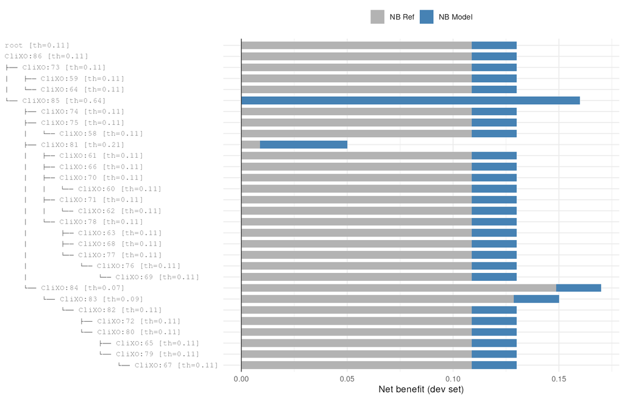

**Figure 4.** Net benefit of model vs. reference at selected thresholds — LOPE — Chorioamnionitis (T3) (Fig 3B, cx).

Table 5. Confusion matrices — LOPE — Chorioamnionitis (T3) (Fig 3B, cx).

| Ontology | PPV/TPR (Dev) | PPV/TPR (Test) | NPV/TNR (Dev) | NPV/TNR (Test) | C1 | C2 | C3 | C4 | Reported |
| --- | --- | --- | --- | --- | --- | --- | --- | --- | --- |
| root (CDO1, PLIN2, CCSAP, BCAR3, DOCK8, SPAG4, BHLHE40†, NECTIN4, SIGLEC6, PTPRD, SFXN3, LDLR, CORO2A, CCDC6, TACC1, SELL, NEDD4L, SLCO4A1, SPON1, PFKFB3, GDA, APLN, IGF1, PIK3R1, SLC11A1, SLA, KRT19,… | 22.9% (20.2, 25.6) / 100.0% (100.0, 100.0) | 3.0% (2.6, 3.4) / 100.0% (100.0, 100.0) | — / 0.0% (0.0, 0.0) | — / 0.0% (0.0, 0.0) | ✓\| | ✓\| | ✓ |  | root |
| CliXO:86 (CDO1, PLIN2, CCSAP, BCAR3, DOCK8, SPAG4, BHLHE40, NECTIN4, SIGLEC6, PTPRD, SFXN3, LDLR, CORO2A, CCDC6, TACC1, SELL, NEDD4L, SLCO4A1, SPON1, PFKFB3, GDA, APLN, IGF1, PIK3R1, SLC11A1, SLA†, KR… | 22.9% (20.2, 25.6) / 100.0% (100.0, 100.0) | 3.0% (2.6, 3.4) / 100.0% (100.0, 100.0) | — / 0.0% (0.0, 0.0) | — / 0.0% (0.0, 0.0) | ✓\| | ✓\| | ✓ | ✓ | CliXO:86 |
| ├── CliXO:73 (DOCK8, GDA, ANKRD13A, HINT3, CHMP2B) | 22.9% (20.2, 25.6) / 100.0% (100.0, 100.0) | 3.0% (2.6, 3.4) / 100.0% (100.0, 100.0) | — / 0.0% (0.0, 0.0) | — / 0.0% (0.0, 0.0) | ✓\| | ✓\| |  | ✓ | CliXO:86 |
| │ ├── CliXO:59 (GDA, ANKRD13A) | 22.9% (20.2, 25.6) / 100.0% (100.0, 100.0) | 3.0% (2.6, 3.4) / 100.0% (100.0, 100.0) | — / 0.0% (0.0, 0.0) | — / 0.0% (0.0, 0.0) | ✓\| | ✓\| |  | ✓ | CliXO:86 |
| │ └── CliXO:64 (HINT3, CHMP2B) | 22.9% (20.2, 25.6) / 100.0% (100.0, 100.0) | 3.0% (2.6, 3.4) / 100.0% (100.0, 100.0) | — / 0.0% (0.0, 0.0) | — / 0.0% (0.0, 0.0) | ✓\| | ✓\| |  |  |  |
| └── CliXO:85 (CDO1, PLIN2, CCSAP, BCAR3, DOCK8, SPAG4, BHLHE40, NECTIN4, SIGLEC6, PTPRD, SFXN3, LDLR, CORO2A, CCDC6, TACC1, SELL, NEDD4L, SLCO4A1, SPON1, PFKFB3, APLN, IGF1, PIK3R1, SLC11A1, SLA, KRT1… | 100.0% (100.0, 100.0) / 70.3% (65.3, 75.4) | 3.0% (2.6, 3.4) / 100.0% (100.0, 100.0) | 92.0% (90.5, 93.5) / 100.0% (100.0, 100.0) | — / 0.0% (0.0, 0.0) | ✓\| | \| |  |  |  |
| ├── CliXO:74 (TACC1, SYDE1, EFNB1, SH3PXD2A, ZMYND8, RAPGEF3) | 22.9% (20.2, 25.6) / 100.0% (100.0, 100.0) | 3.0% (2.6, 3.4) / 100.0% (100.0, 100.0) | — / 0.0% (0.0, 0.0) | — / 0.0% (0.0, 0.0) | ✓\| | ✓\| |  |  |  |
| ├── CliXO:75 (BHLHE40, PFKFB3, SLC11A1, GPR146, P4HA1, ZMYND8, ERO1A) | 22.9% (20.2, 25.6) / 100.0% (100.0, 100.0) | 3.0% (2.6, 3.4) / 100.0% (100.0, 100.0) | — / 0.0% (0.0, 0.0) | — / 0.0% (0.0, 0.0) | ✓\| | ✓\| |  |  |  |
| │ └── CliXO:58 (P4HA1, ERO1A) | 22.9% (20.2, 25.6) / 100.0% (100.0, 100.0) | 3.0% (2.6, 3.4) / 100.0% (100.0, 100.0) | — / 0.0% (0.0, 0.0) | — / 0.0% (0.0, 0.0) | ✓\| | ✓\| |  |  |  |
| ├── CliXO:81 (DOCK8, PTPRD, LDLR, CCDC6, SELL, NEDD4L, SPON1, PFKFB3, APLN, IGF1, SLC11A1, SLA, ERRFI1, TUBB4B, SMPDL3A, PAK2, FAP, ZNF555, ICA1, MYC, ASAH1, ZEB2) | 26.9% (23.6, 30.3) / 88.2% (84.6, 91.7) | 3.0% (2.6, 3.4) / 100.0% (100.0, 100.0) | 87.8% (84.1, 91.6) / 28.9% (25.6, 32.3) | — / 0.0% (0.0, 0.0) | ✓\| | ✓\| |  |  | CliXO:86 |
| │ ├── CliXO:61 (SPON1, TUBB4B) | 22.9% (20.2, 25.6) / 100.0% (100.0, 100.0) | 3.0% (2.6, 3.4) / 100.0% (100.0, 100.0) | — / 0.0% (0.0, 0.0) | — / 0.0% (0.0, 0.0) | ✓\| | ✓\| |  |  |  |
| │ ├── CliXO:66 (LDLR, TUBB4B, MYC) | 22.9% (20.2, 25.6) / 100.0% (100.0, 100.0) | 3.0% (2.6, 3.4) / 100.0% (100.0, 100.0) | — / 0.0% (0.0, 0.0) | — / 0.0% (0.0, 0.0) | ✓\| | ✓\| |  |  |  |
| │ ├── CliXO:70 (CCDC6, SMPDL3A, PAK2, ASAH1) | 22.9% (20.2, 25.6) / 100.0% (100.0, 100.0) | 3.0% (2.6, 3.4) / 100.0% (100.0, 100.0) | — / 0.0% (0.0, 0.0) | — / 0.0% (0.0, 0.0) | ✓\| | ✓\| |  |  |  |
| │ │ └── CliXO:60 (CCDC6, PAK2) | 22.9% (20.2, 25.6) / 100.0% (100.0, 100.0) | 3.0% (2.6, 3.4) / 100.0% (100.0, 100.0) | — / 0.0% (0.0, 0.0) | — / 0.0% (0.0, 0.0) | ✓\| | ✓\| |  |  |  |
| │ ├── CliXO:71 (SLC11A1, SLA, FAP, MYC) | 22.9% (20.2, 25.6) / 100.0% (100.0, 100.0) | 3.0% (2.6, 3.4) / 100.0% (100.0, 100.0) | — / 0.0% (0.0, 0.0) | — / 0.0% (0.0, 0.0) | ✓\| | ✓\| |  |  | CliXO:86 |
| │ │ └── CliXO:62 (SLA, MYC) | 22.9% (20.2, 25.6) / 100.0% (100.0, 100.0) | 3.0% (2.6, 3.4) / 100.0% (100.0, 100.0) | — / 0.0% (0.0, 0.0) | — / 0.0% (0.0, 0.0) | ✓\| | ✓\| |  |  | CliXO:86 |
| │ └── CliXO:78 (DOCK8, PTPRD, NEDD4L, SPON1, APLN, IGF1†, PAK2, FAP, ZNF555, ICA1, ASAH1, ZEB2) | 22.9% (20.2, 25.6) / 100.0% (100.0, 100.0) | 3.0% (2.6, 3.4) / 100.0% (100.0, 100.0) | — / 0.0% (0.0, 0.0) | — / 0.0% (0.0, 0.0) | ✓\| | ✓\| | ✓ |  | CliXO:78 |
| │ ├── CliXO:63 (ZNF555, ZEB2) | 22.9% (20.2, 25.6) / 100.0% (100.0, 100.0) | 3.0% (2.6, 3.4) / 100.0% (100.0, 100.0) | — / 0.0% (0.0, 0.0) | — / 0.0% (0.0, 0.0) | ✓\| | ✓\| |  |  |  |
| │ ├── CliXO:68 (NEDD4L, PAK2, ASAH1) | 22.9% (20.2, 25.6) / 100.0% (100.0, 100.0) | 3.0% (2.6, 3.4) / 100.0% (100.0, 100.0) | — / 0.0% (0.0, 0.0) | — / 0.0% (0.0, 0.0) | ✓\| | ✓\| |  |  |  |
| │ └── CliXO:77 (DOCK8, PTPRD, SPON1, APLN, IGF1, PAK2, ICA1, ASAH1, ZEB2) | 22.9% (20.2, 25.6) / 100.0% (100.0, 100.0) | 3.0% (2.6, 3.4) / 100.0% (100.0, 100.0) | — / 0.0% (0.0, 0.0) | — / 0.0% (0.0, 0.0) | ✓\| | ✓\| |  |  | CliXO:78 |
| │ └── CliXO:76 (DOCK8, PTPRD, SPON1, APLN, IGF1, PAK2, ASAH1, ZEB2) | 22.9% (20.2, 25.6) / 100.0% (100.0, 100.0) | 3.0% (2.6, 3.4) / 100.0% (100.0, 100.0) | — / 0.0% (0.0, 0.0) | — / 0.0% (0.0, 0.0) | ✓\| | ✓\| |  |  | CliXO:78 |
| │ └── CliXO:69 (PTPRD, SPON1, IGF1, ZEB2) | 22.9% (20.2, 25.6) / 100.0% (100.0, 100.0) | 3.0% (2.6, 3.4) / 100.0% (100.0, 100.0) | — / 0.0% (0.0, 0.0) | — / 0.0% (0.0, 0.0) | ✓\| | ✓\| |  |  | CliXO:78 |
| └── CliXO:84 (CDO1, PLIN2, CCSAP, BCAR3, SPAG4, BHLHE40, NECTIN4, SIGLEC6, SFXN3, CORO2A, TACC1, SLCO4A1, PIK3R1, KRT19, SYDE1, ERRFI1, GRHL1, CEBPA, GBE1, GPR146, CCDC127, CA4, LEP, EFNB1, P4HA1, SH3… | 22.9% (20.2, 25.6) / 100.0% (100.0, 100.0) | 3.0% (2.6, 3.4) / 100.0% (100.0, 100.0) | — / 0.0% (0.0, 0.0) | — / 0.0% (0.0, 0.0) | ✓\| | ✓\| |  |  | root |
| └── CliXO:83 (CDO1, PLIN2, CCSAP, BCAR3, SPAG4, BHLHE40, NECTIN4, SIGLEC6, SFXN3, CORO2A, TACC1, SLCO4A1, PIK3R1, KRT19, SYDE1, ERRFI1, GRHL1, CEBPA, GBE1, GPR146, CCDC127, LEP, EFNB1, P4HA1, SH3PXD2A… | 22.9% (20.2, 25.6) / 100.0% (100.0, 100.0) | 3.0% (2.6, 3.4) / 100.0% (100.0, 100.0) | — / 0.0% (0.0, 0.0) | — / 0.0% (0.0, 0.0) | ✓\| | ✓\| |  |  | root |
| └── CliXO:82 (CDO1, PLIN2, CCSAP, BCAR3, SPAG4, BHLHE40, NECTIN4, SIGLEC6, SFXN3, CORO2A, KRT19, SYDE1, ERRFI1, GRHL1, GPR146, LEP, EFNB1, P4HA1, SH3PXD2A, ZMYND8, SLCO2A1, GPT2, ERO1A, ANKRD37) | 22.9% (20.2, 25.6) / 100.0% (100.0, 100.0) | 3.0% (2.6, 3.4) / 100.0% (100.0, 100.0) | — / 0.0% (0.0, 0.0) | — / 0.0% (0.0, 0.0) | ✓\| | ✓\| |  |  | root |
| ├── CliXO:72 (KRT19, LEP, SH3PXD2A, SLCO2A1) | 22.9% (20.2, 25.6) / 100.0% (100.0, 100.0) | 3.0% (2.6, 3.4) / 100.0% (100.0, 100.0) | — / 0.0% (0.0, 0.0) | — / 0.0% (0.0, 0.0) | ✓\| | ✓\| |  |  |  |
| └── CliXO:80 (PLIN2, CCSAP, SPAG4, BHLHE40, NECTIN4, SIGLEC6, SFXN3, CORO2A, KRT19, SYDE1, ERRFI1, GRHL1, GPR146, LEP, EFNB1, P4HA1, SH3PXD2A, GPT2, ERO1A, ANKRD37) | 22.9% (20.2, 25.6) / 100.0% (100.0, 100.0) | 3.0% (2.6, 3.4) / 100.0% (100.0, 100.0) | — / 0.0% (0.0, 0.0) | — / 0.0% (0.0, 0.0) | ✓\| | ✓\| |  |  | root |
| ├── CliXO:65 (BHLHE40, ANKRD37) | 22.9% (20.2, 25.6) / 100.0% (100.0, 100.0) | 3.0% (2.6, 3.4) / 100.0% (100.0, 100.0) | — / 0.0% (0.0, 0.0) | — / 0.0% (0.0, 0.0) | ✓\| | ✓\| |  |  | root |
| └── CliXO:79 (PLIN2, CCSAP, SPAG4, BHLHE40, NECTIN4, SFXN3, CORO2A, KRT19, SYDE1, GRHL1, GPR146, LEP, P4HA1, SH3PXD2A, GPT2, ERO1A) | 22.9% (20.2, 25.6) / 100.0% (100.0, 100.0) | 3.0% (2.6, 3.4) / 100.0% (100.0, 100.0) | — / 0.0% (0.0, 0.0) | — / 0.0% (0.0, 0.0) | ✓\| | ✓\| |  |  |  |
| └── CliXO:67 (NECTIN4, SFXN3, ERO1A) | 22.9% (20.2, 25.6) / 100.0% (100.0, 100.0) | 3.0% (2.6, 3.4) / 100.0% (100.0, 100.0) | — / 0.0% (0.0, 0.0) | — / 0.0% (0.0, 0.0) | ✓\| | ✓\| |  |  |  |

**Reported column:** The ontology from the manuscript (Tables 1–2) to which this row’s eligible genes belong. An ontology is reported if it passes all three criteria (C1, C2, C3) and its eligible gene set is not a strict subset of another passing ontology’s gene set. Rows are empty when the ontology has no eligible genes or does not pass all three criteria.

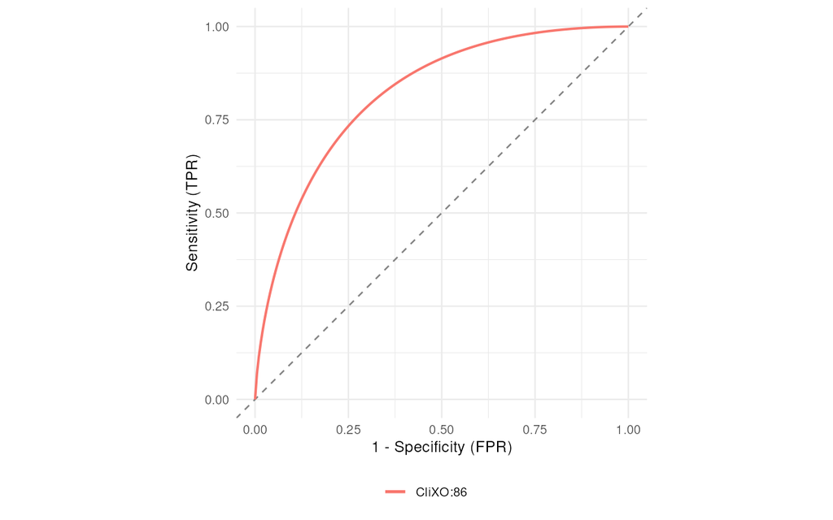

**Figure 6.** ROC curves for ontologies passing C1–C4 — LOPE — Chorioamnionitis (T3) (Fig 3B, cx).

Table 7. AUROC, AUPRC, and calibration — LOPE — Chorioamnionitis (T3) (Fig 3B, cx).

| Ontology | AUC-ROC (Dev) | AUC-ROC (Test) | AUC-PRC (Dev) | AUC-PRC (Test) | RMSE (Dev) | RMSE (Test) | C1 | C2 | C3 | C4 | Reported |
| --- | --- | --- | --- | --- | --- | --- | --- | --- | --- | --- | --- |
| root (CDO1, PLIN2, CCSAP, BCAR3, DOCK8, SPAG4, BHLHE40†, NECTIN4, SIGLEC6, PTPRD, SFXN3, LDLR, CORO2A, CCDC6, TACC1, SELL, NEDD4L, SLCO4A1, SPON1, PFKFB3, GDA, APLN, IGF1, PIK3R1, SLC11A1, SLA, KRT19,… | 0.199 (0.168, 0.231) | 0.275 (0.267, 0.283) | 0.088 | 0.016 | 0.669 (±0.0104) | 0.533 (±0.0070) | ✓\| | ✓\| | ✓ |  | root |
| CliXO:86 (CDO1, PLIN2, CCSAP, BCAR3, DOCK8, SPAG4, BHLHE40, NECTIN4, SIGLEC6, PTPRD, SFXN3, LDLR, CORO2A, CCDC6, TACC1, SELL, NEDD4L, SLCO4A1, SPON1, PFKFB3, GDA, APLN, IGF1, PIK3R1, SLC11A1, SLA†, KR… | 0.783 (0.745, 0.821) | 0.725 (0.717, 0.733) | 0.318 | 0.516 | 0.518 (±0.0039) | 0.555 (±0.0010) | ✓\| | ✓\| | ✓ | ✓ | CliXO:86 |
| ├── CliXO:73 (DOCK8, GDA, ANKRD13A, HINT3, CHMP2B) | 0.810 (0.782, 0.839) | 0.725 (0.717, 0.733) | 0.675 | 0.516 | 0.545 (±0.0051) | 0.598 (±0.0011) | ✓\| | ✓\| |  | ✓ | CliXO:86 |
| │ ├── CliXO:59 (GDA, ANKRD13A) | 0.810 (0.782, 0.839) | 0.725 (0.717, 0.733) | 0.476 | 0.516 | 0.566 (±0.0085) | 0.666 (±0.0025) | ✓\| | ✓\| |  | ✓ | CliXO:86 |
| │ └── CliXO:64 (HINT3, CHMP2B) | 0.500 (0.500, 0.500) | 0.500 (0.500, 0.500) | 0.609 | 0.516 | 0.875 (±0.0154) | 0.982 (±0.0020) | ✓\| | ✓\| |  |  |  |
| └── CliXO:85 (CDO1, PLIN2, CCSAP, BCAR3, DOCK8, SPAG4, BHLHE40, NECTIN4, SIGLEC6, PTPRD, SFXN3, LDLR, CORO2A, CCDC6, TACC1, SELL, NEDD4L, SLCO4A1, SPON1, PFKFB3, APLN, IGF1, PIK3R1, SLC11A1, SLA, KRT1… | 0.693 (0.656, 0.730) | 0.500 (0.500, 0.500) | 0.376 | 0.516 | 0.535 (±0.0084) | 0.649 (±0.0010) | ✓\| | \| |  |  |  |
| ├── CliXO:74 (TACC1, SYDE1, EFNB1, SH3PXD2A, ZMYND8, RAPGEF3) | 0.500 (0.500, 0.500) | 0.500 (0.500, 0.500) | 0.609 | 0.516 | 0.875 (±0.0154) | 0.982 (±0.0020) | ✓\| | ✓\| |  |  |  |
| ├── CliXO:75 (BHLHE40, PFKFB3, SLC11A1, GPR146, P4HA1, ZMYND8, ERO1A) | 0.208 (0.181, 0.234) | 0.500 (0.500, 0.500) | 0.088 | 0.516 | 0.679 (±0.0102) | 0.214 (±0.0060) | ✓\| | ✓\| |  |  |  |
| │ └── CliXO:58 (P4HA1, ERO1A) | 0.500 (0.500, 0.500) | 0.500 (0.500, 0.500) | 0.609 | 0.516 | 0.875 (±0.0154) | 0.982 (±0.0020) | ✓\| | ✓\| |  |  |  |
| ├── CliXO:81 (DOCK8, PTPRD, LDLR, CCDC6, SELL, NEDD4L, SPON1, PFKFB3, APLN, IGF1, SLC11A1, SLA, ERRFI1, TUBB4B, SMPDL3A, PAK2, FAP, ZNF555, ICA1, MYC, ASAH1, ZEB2) | 0.563 (0.525, 0.602) | 0.500 (0.500, 0.500) | 0.102 | 0.516 | 0.526 (±0.0139) | 0.623 (±0.0008) | ✓\| | ✓\| |  |  | CliXO:86 |
| │ ├── CliXO:61 (SPON1, TUBB4B) | 0.500 (0.500, 0.500) | 0.500 (0.500, 0.500) | 0.609 | 0.516 | 0.875 (±0.0154) | 0.982 (±0.0020) | ✓\| | ✓\| |  |  |  |
| │ ├── CliXO:66 (LDLR, TUBB4B, MYC) | 0.500 (0.500, 0.500) | 0.500 (0.500, 0.500) | 0.609 | 0.516 | 0.875 (±0.0154) | 0.982 (±0.0020) | ✓\| | ✓\| |  |  |  |
| │ ├── CliXO:70 (CCDC6, SMPDL3A, PAK2, ASAH1) | 0.500 (0.500, 0.500) | 0.500 (0.500, 0.500) | 0.609 | 0.516 | 0.875 (±0.0154) | 0.982 (±0.0020) | ✓\| | ✓\| |  |  |  |
| │ │ └── CliXO:60 (CCDC6, PAK2) | 0.500 (0.500, 0.500) | 0.500 (0.500, 0.500) | 0.609 | 0.516 | 0.875 (±0.0154) | 0.982 (±0.0020) | ✓\| | ✓\| |  |  |  |
| │ ├── CliXO:71 (SLC11A1, SLA, FAP, MYC) | 0.856 (0.829, 0.883) | 0.500 (0.500, 0.500) | 0.504 | 0.516 | 0.748 (±0.0129) | 0.865 (±0.0017) | ✓\| | ✓\| |  |  | CliXO:86 |
| │ │ └── CliXO:62 (SLA, MYC) | 0.500 (0.500, 0.500) | 0.500 (0.500, 0.500) | 0.609 | 0.516 | 0.752 (±0.0127) | 0.842 (±0.0017) | ✓\| | ✓\| |  |  | CliXO:86 |
| │ └── CliXO:78 (DOCK8, PTPRD, NEDD4L, SPON1, APLN, IGF1†, PAK2, FAP, ZNF555, ICA1, ASAH1, ZEB2) | 0.217 (0.184, 0.250) | 0.500 (0.500, 0.500) | 0.088 | 0.516 | 0.616 (±0.0115) | 0.206 (±0.0066) | ✓\| | ✓\| | ✓ |  | CliXO:78 |
| │ ├── CliXO:63 (ZNF555, ZEB2) | 0.500 (0.500, 0.500) | 0.500 (0.500, 0.500) | 0.609 | 0.516 | 0.875 (±0.0154) | 0.982 (±0.0020) | ✓\| | ✓\| |  |  |  |
| │ ├── CliXO:68 (NEDD4L, PAK2, ASAH1) | 0.500 (0.500, 0.500) | 0.500 (0.500, 0.500) | 0.609 | 0.516 | 0.875 (±0.0154) | 0.982 (±0.0020) | ✓\| | ✓\| |  |  |  |
| │ └── CliXO:77 (DOCK8, PTPRD, SPON1, APLN, IGF1, PAK2, ICA1, ASAH1, ZEB2) | 0.217 (0.184, 0.250) | 0.500 (0.500, 0.500) | 0.088 | 0.516 | 0.575 (±0.0068) | 0.361 (±0.0016) | ✓\| | ✓\| |  |  | CliXO:78 |
| │ └── CliXO:76 (DOCK8, PTPRD, SPON1, APLN, IGF1, PAK2, ASAH1, ZEB2) | 0.783 (0.750, 0.816) | 0.500 (0.500, 0.500) | 0.675 | 0.516 | 0.579 (±0.0061) | 0.630 (±0.0009) | ✓\| | ✓\| |  |  | CliXO:78 |
| │ └── CliXO:69 (PTPRD, SPON1, IGF1, ZEB2) | 0.783 (0.750, 0.816) | 0.500 (0.500, 0.500) | 0.675 | 0.516 | 0.681 (±0.0107) | 0.784 (±0.0015) | ✓\| | ✓\| |  |  | CliXO:78 |
| └── CliXO:84 (CDO1, PLIN2, CCSAP, BCAR3, SPAG4, BHLHE40, NECTIN4, SIGLEC6, SFXN3, CORO2A, TACC1, SLCO4A1, PIK3R1, KRT19, SYDE1, ERRFI1, GRHL1, CEBPA, GBE1, GPR146, CCDC127, CA4, LEP, EFNB1, P4HA1, SH3… | 0.208 (0.181, 0.234) | 0.500 (0.500, 0.500) | 0.088 | 0.516 | 0.664 (±0.0125) | 0.176 (±0.0090) | ✓\| | ✓\| |  |  | root |
| └── CliXO:83 (CDO1, PLIN2, CCSAP, BCAR3, SPAG4, BHLHE40, NECTIN4, SIGLEC6, SFXN3, CORO2A, TACC1, SLCO4A1, PIK3R1, KRT19, SYDE1, ERRFI1, GRHL1, CEBPA, GBE1, GPR146, CCDC127, LEP, EFNB1, P4HA1, SH3PXD2A… | 0.208 (0.181, 0.234) | 0.500 (0.500, 0.500) | 0.088 | 0.516 | 0.659 (±0.0121) | 0.180 (±0.0085) | ✓\| | ✓\| |  |  | root |
| └── CliXO:82 (CDO1, PLIN2, CCSAP, BCAR3, SPAG4, BHLHE40, NECTIN4, SIGLEC6, SFXN3, CORO2A, KRT19, SYDE1, ERRFI1, GRHL1, GPR146, LEP, EFNB1, P4HA1, SH3PXD2A, ZMYND8, SLCO2A1, GPT2, ERO1A, ANKRD37) | 0.208 (0.181, 0.234) | 0.500 (0.500, 0.500) | 0.088 | 0.516 | 0.629 (±0.0081) | 0.284 (±0.0033) | ✓\| | ✓\| |  |  | root |
| ├── CliXO:72 (KRT19, LEP, SH3PXD2A, SLCO2A1) | 0.500 (0.500, 0.500) | 0.500 (0.500, 0.500) | 0.609 | 0.516 | 0.875 (±0.0154) | 0.982 (±0.0020) | ✓\| | ✓\| |  |  |  |
| └── CliXO:80 (PLIN2, CCSAP, SPAG4, BHLHE40, NECTIN4, SIGLEC6, SFXN3, CORO2A, KRT19, SYDE1, ERRFI1, GRHL1, GPR146, LEP, EFNB1, P4HA1, SH3PXD2A, GPT2, ERO1A, ANKRD37) | 0.208 (0.181, 0.234) | 0.500 (0.500, 0.500) | 0.088 | 0.516 | 0.626 (±0.0079) | 0.292 (±0.0031) | ✓\| | ✓\| |  |  | root |
| ├── CliXO:65 (BHLHE40, ANKRD37) | 0.792 (0.766, 0.819) | 0.500 (0.500, 0.500) | 0.694 | 0.516 | 0.698 (±0.0114) | 0.809 (±0.0016) | ✓\| | ✓\| |  |  | root |
| └── CliXO:79 (PLIN2, CCSAP, SPAG4, BHLHE40, NECTIN4, SFXN3, CORO2A, KRT19, SYDE1, GRHL1, GPR146, LEP, P4HA1, SH3PXD2A, GPT2, ERO1A) | 0.208 (0.181, 0.234) | 0.500 (0.500, 0.500) | 0.088 | 0.516 | 0.679 (±0.0102) | 0.214 (±0.0060) | ✓\| | ✓\| |  |  |  |
| │ └── CliXO:58 (P4HA1, ERO1A) | 0.500 (0.500, 0.500) | 0.500 (0.500, 0.500) | 0.609 | 0.516 | 0.875 (±0.0154) | 0.982 (±0.0020) | ✓\| | ✓\| |  |  |  |
| └── CliXO:67 (NECTIN4, SFXN3, ERO1A) | 0.500 (0.500, 0.500) | 0.500 (0.500, 0.500) | 0.609 | 0.516 | 0.875 (±0.0154) | 0.982 (±0.0020) | ✓\| | ✓\| |  |  |  |

**Reported column:** The ontology from the manuscript (Tables 1–2) to which this row’s eligible genes belong. An ontology is reported if it passes all three criteria (C1, C2, C3) and its eligible gene set is not a strict subset of another passing ontology’s gene set. Rows are empty when the ontology has no eligible genes or does not pass all three criteria.

# LOPE — HELLP syndrome (T3) (Fig 3C, cx)

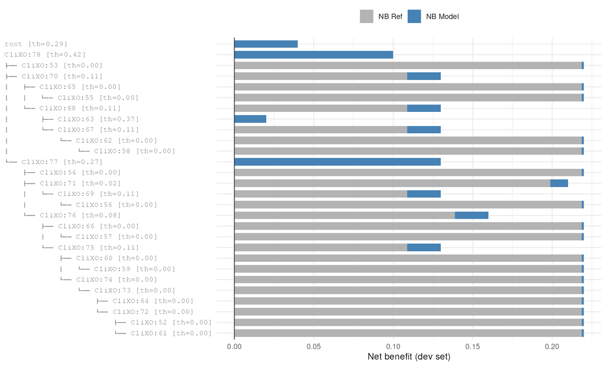

**Figure 8.** Net benefit of model vs. reference at selected thresholds — LOPE — HELLP syndrome (T3) (Fig 3C, cx).

Table 9. Confusion matrices — LOPE — HELLP syndrome (T3) (Fig 3C, cx).

| Ontology | PPV/TPR (Dev) | PPV/TPR (Test) | NPV/TNR (Dev) | NPV/TNR (Test) | C1 | C2 | C3 | C4 | Reported |
| --- | --- | --- | --- | --- | --- | --- | --- | --- | --- |
| root (SFXN3, GBE1, ASAH1, KLF3, GPT2, LEP, SH3PXD2A, PKM, GPX3, FLNB, IGF1, CEBPD, ERRFI1, CCDC127, PDE5A, IGSF8, CDO1, CCSAP, SYDE1, ERO1A, SLC25A4, TOR1B, FCN3, BCAR3, NFIL3, LDLR, EFNB1, VEGFA, GRH… | 34.9% (30.5, 39.2) / 86.1% (81.6, 90.7) | 3.4% (3.0, 3.9) / 100.0% (100.0, 100.0) | 93.5% (91.4, 95.5) / 52.9% (48.4, 57.3) | — / 0.5% (0.4, 0.6) | ✓\| | \| |  | ✓ |  |
| CliXO:78 (SFXN3, GBE1, ASAH1, KLF3, GPT2, LEP, SH3PXD2A, PKM, GPX3, FLNB, IGF1, CEBPD, ERRFI1, CCDC127, PDE5A, IGSF8, CDO1, CCSAP, SYDE1, ERO1A, SLC25A4, TOR1B, FCN3, BCAR3, NFIL3, LDLR, EFNB1, VEGFA,… | 59.7% (54.9, 64.6) / 86.1% (81.6, 90.7) | 3.4% (3.0, 3.9) / 100.0% (100.0, 100.0) | 95.6% (94.1, 97.1) / 83.5% (81.1, 85.8) | — / 0.5% (0.4, 0.6) | ✓\| | \| |  |  |  |
| ├── CliXO:53 (LDLR, SPON1) | 22.3% (19.8, 24.8) / 100.0% (100.0, 100.0) | 3.4% (2.9, 3.9) / 100.0% (100.0, 100.0) | — / 0.0% (0.0, 0.0) | — / 0.0% (0.0, 0.0) | ✓\| | ✓\| |  |  |  |
| ├── CliXO:70 (ASAH1, IGF1, PDE5A†, ZEB2, GMFB, APLN, AZIN1, NHLRC2, SPON1, IQGAP2, ZNF555) | 22.3% (19.8, 24.8) / 100.0% (100.0, 100.0) | 3.4% (2.9, 3.9) / 100.0% (100.0, 100.0) | — / 0.0% (0.0, 0.0) | — / 0.0% (0.0, 0.0) | ✓\| | ✓\| | ✓ | ✓ | CliXO:70 |
| │ ├── CliXO:65 (GMFB, AZIN1, NHLRC2, IQGAP2) | 22.3% (19.8, 24.8) / 100.0% (100.0, 100.0) | 3.4% (2.9, 3.9) / 100.0% (100.0, 100.0) | — / 0.0% (0.0, 0.0) | — / 0.0% (0.0, 0.0) | ✓\| | ✓\| |  |  |  |
| │ │ └── CliXO:55 (GMFB, AZIN1) | 22.3% (19.8, 24.8) / 100.0% (100.0, 100.0) | 3.4% (2.9, 3.9) / 100.0% (100.0, 100.0) | — / 0.0% (0.0, 0.0) | — / 0.0% (0.0, 0.0) | ✓\| | ✓\| |  |  |  |
| │ └── CliXO:68 (ASAH1, IGF1, PDE5A, ZEB2, APLN, AZIN1, NHLRC2, SPON1, IQGAP2, ZNF555) | 22.3% (19.8, 24.8) / 100.0% (100.0, 100.0) | 3.4% (2.9, 3.9) / 100.0% (100.0, 100.0) | — / 0.0% (0.0, 0.0) | — / 0.0% (0.0, 0.0) | ✓\| | ✓\| |  | ✓ | CliXO:70 |
| │ ├── CliXO:63 (PDE5A, AZIN1, NHLRC2, IQGAP2) | 40.2% (35.5, 45.0) / 100.0% (100.0, 100.0) | 3.4% (3.0, 3.9) / 100.0% (100.0, 100.0) | 100.0% (100.0, 100.0) / 56.1% (51.4, 60.8) | — / 0.9% (0.7, 1.1) | ✓\| | \| |  | ✓ | CliXO:70 |
| │ └── CliXO:67 (IGF1, PDE5A, ZEB2, SPON1, ZNF555) | 22.3% (19.8, 24.8) / 100.0% (100.0, 100.0) | 3.4% (2.9, 3.9) / 100.0% (100.0, 100.0) | — / 0.0% (0.0, 0.0) | — / 0.0% (0.0, 0.0) | ✓\| | ✓\| |  | ✓ |  |
| │ └── CliXO:62 (IGF1, ZEB2, SPON1) | 22.3% (19.8, 24.8) / 100.0% (100.0, 100.0) | 3.4% (2.9, 3.9) / 100.0% (100.0, 100.0) | — / 0.0% (0.0, 0.0) | — / 0.0% (0.0, 0.0) | ✓\| | ✓\| |  |  |  |
| │ └── CliXO:58 (IGF1, ZEB2) | 22.3% (19.8, 24.8) / 100.0% (100.0, 100.0) | 3.4% (2.9, 3.9) / 100.0% (100.0, 100.0) | — / 0.0% (0.0, 0.0) | — / 0.0% (0.0, 0.0) | ✓\| | ✓\| |  |  |  |
| └── CliXO:77 (SFXN3, GBE1, KLF3, GPT2, LEP, SH3PXD2A, PKM, GPX3, FLNB, CEBPD, ERRFI1, CCDC127, IGSF8, CDO1, CCSAP, SYDE1, ERO1A, SLC25A4, TOR1B, FCN3, BCAR3, NFIL3, LDLR, EFNB1, VEGFA, GRHL1, KRT19, Z… | 54.5% (49.2, 59.8) / 86.1% (81.6, 90.7) | 3.4% (2.9, 3.9) / 100.0% (100.0, 100.0) | 95.4% (93.9, 97.0) / 79.7% (77.3, 82.1) | — / 0.0% (0.0, 0.0) | ✓\| | \| |  |  | CliXO:71 |
| ├── CliXO:54 (GPX3, FCN3) | 22.3% (19.8, 24.8) / 100.0% (100.0, 100.0) | 3.4% (2.9, 3.9) / 100.0% (100.0, 100.0) | — / 0.0% (0.0, 0.0) | — / 0.0% (0.0, 0.0) | ✓\| | ✓\| |  |  |  |
| ├── CliXO:71 (GPT2, FLNB, CEBPD, ERRFI1, IGSF8, SLC25A4, TOR1B, LDLR, VEGFA, FAM43A†, CEBPA, PREP) | 22.3% (19.8, 24.8) / 100.0% (100.0, 100.0) | 3.4% (2.9, 3.9) / 100.0% (100.0, 100.0) | — / 0.0% (0.0, 0.0) | — / 0.0% (0.0, 0.0) | ✓\| | ✓\| | ✓ |  | CliXO:71 |
| │ └── CliXO:69 (GPT2, FLNB, CEBPD, ERRFI1, IGSF8, SLC25A4, TOR1B, LDLR, FAM43A, PREP) | 22.3% (19.8, 24.8) / 100.0% (100.0, 100.0) | 3.4% (2.9, 3.9) / 100.0% (100.0, 100.0) | — / 0.0% (0.0, 0.0) | — / 0.0% (0.0, 0.0) | ✓\| | ✓\| |  |  |  |
| │ └── CliXO:56 (LDLR, PREP) | 22.3% (19.8, 24.8) / 100.0% (100.0, 100.0) | 3.4% (2.9, 3.9) / 100.0% (100.0, 100.0) | — / 0.0% (0.0, 0.0) | — / 0.0% (0.0, 0.0) | ✓\| | ✓\| |  |  |  |
| └── CliXO:76 (SFXN3, GBE1, KLF3, GPT2, LEP, SH3PXD2A, PKM, GPX3, FLNB, CEBPD, ERRFI1, CCDC127, IGSF8, CDO1, CCSAP, SYDE1, ERO1A, TOR1B, BCAR3, NFIL3, EFNB1, VEGFA, GRHL1, KRT19, ZMYND8, FAM43A, GPR146… | 22.3% (19.8, 24.8) / 100.0% (100.0, 100.0) | 3.4% (2.9, 3.9) / 100.0% (100.0, 100.0) | — / 0.0% (0.0, 0.0) | — / 0.0% (0.0, 0.0) | ✓\| | ✓\| |  |  | CliXO:71 |
| ├── CliXO:66 (GPX3, CEBPD, VEGFA, GPR146, P4HA1) | 22.3% (19.8, 24.8) / 100.0% (100.0, 100.0) | 3.4% (2.9, 3.9) / 100.0% (100.0, 100.0) | — / 0.0% (0.0, 0.0) | — / 0.0% (0.0, 0.0) | ✓\| | ✓\| |  |  |  |
| │ └── CliXO:57 (GPX3, VEGFA) | 22.3% (19.8, 24.8) / 100.0% (100.0, 100.0) | 3.4% (2.9, 3.9) / 100.0% (100.0, 100.0) | — / 0.0% (0.0, 0.0) | — / 0.0% (0.0, 0.0) | ✓\| | ✓\| |  |  |  |
| └── CliXO:75 (SFXN3, GBE1, KLF3, GPT2, LEP, SH3PXD2A, PKM, FLNB, ERRFI1, CCDC127, CDO1, CCSAP, SYDE1, ERO1A, BCAR3, NFIL3, EFNB1, GRHL1, KRT19, ZMYND8, FAM43A, GPR146, NECTIN4, PIK3R1, SPAG4, BHLHE40,… | 22.3% (19.8, 24.8) / 100.0% (100.0, 100.0) | 3.4% (2.9, 3.9) / 100.0% (100.0, 100.0) | — / 0.0% (0.0, 0.0) | — / 0.0% (0.0, 0.0) | ✓\| | ✓\| |  |  |  |
| ├── CliXO:60 (NFIL3, BHLHE40, ANKRD37) | 22.3% (19.8, 24.8) / 100.0% (100.0, 100.0) | 3.4% (2.9, 3.9) / 100.0% (100.0, 100.0) | — / 0.0% (0.0, 0.0) | — / 0.0% (0.0, 0.0) | ✓\| | ✓\| |  |  |  |
| │ └── CliXO:59 (BHLHE40, ANKRD37) | 22.3% (19.8, 24.8) / 100.0% (100.0, 100.0) | 3.4% (2.9, 3.9) / 100.0% (100.0, 100.0) | — / 0.0% (0.0, 0.0) | — / 0.0% (0.0, 0.0) | ✓\| | ✓\| |  |  |  |
| └── CliXO:74 (SFXN3, GBE1, KLF3, GPT2, LEP, SH3PXD2A, PKM, FLNB, ERRFI1, CDO1, CCSAP, SYDE1, ERO1A, BCAR3, EFNB1, GRHL1, KRT19, ZMYND8, GPR146, NECTIN4, PIK3R1, SPAG4, BHLHE40, CORO2A, ANKRD37, P4HA1,… | 22.3% (19.8, 24.8) / 100.0% (100.0, 100.0) | 3.4% (2.9, 3.9) / 100.0% (100.0, 100.0) | — / 0.0% (0.0, 0.0) | — / 0.0% (0.0, 0.0) | ✓\| | ✓\| |  |  |  |
| └── CliXO:73 (SFXN3, KLF3, GPT2, LEP, SH3PXD2A, PKM, FLNB, ERRFI1, CCSAP, SYDE1, ERO1A, BCAR3, EFNB1, GRHL1, KRT19, GPR146, NECTIN4, SPAG4, BHLHE40, CORO2A, ANKRD37, P4HA1, PLIN2) | 22.3% (19.8, 24.8) / 100.0% (100.0, 100.0) | 3.4% (2.9, 3.9) / 100.0% (100.0, 100.0) | — / 0.0% (0.0, 0.0) | — / 0.0% (0.0, 0.0) | ✓\| | ✓\| |  |  |  |
| ├── CliXO:64 (SFXN3, KLF3, NECTIN4, BHLHE40) | 22.3% (19.8, 24.8) / 100.0% (100.0, 100.0) | 3.4% (2.9, 3.9) / 100.0% (100.0, 100.0) | — / 0.0% (0.0, 0.0) | — / 0.0% (0.0, 0.0) | ✓\| | ✓\| |  |  |  |
| └── CliXO:72 (SFXN3, GPT2, LEP, SH3PXD2A, FLNB, CCSAP, SYDE1, ERO1A, KRT19, GPR146, NECTIN4, SPAG4, BHLHE40, CORO2A, P4HA1, PLIN2) | 22.3% (19.8, 24.8) / 100.0% (100.0, 100.0) | 3.4% (2.9, 3.9) / 100.0% (100.0, 100.0) | — / 0.0% (0.0, 0.0) | — / 0.0% (0.0, 0.0) | ✓\| | ✓\| |  |  |  |
| ├── CliXO:52 (ERO1A, P4HA1) | 22.3% (19.8, 24.8) / 100.0% (100.0, 100.0) | 3.4% (2.9, 3.9) / 100.0% (100.0, 100.0) | — / 0.0% (0.0, 0.0) | — / 0.0% (0.0, 0.0) | ✓\| | ✓\| |  |  |  |
| └── CliXO:61 (SFXN3, ERO1A, NECTIN4) | 22.3% (19.8, 24.8) / 100.0% (100.0, 100.0) | 3.4% (2.9, 3.9) / 100.0% (100.0, 100.0) | — / 0.0% (0.0, 0.0) | — / 0.0% (0.0, 0.0) | ✓\| | ✓\| |  |  |  |

**Reported column:** The ontology from the manuscript (Tables 1–2) to which this row’s eligible genes belong. An ontology is reported if it passes all three criteria (C1, C2, C3) and its eligible gene set is not a strict subset of another passing ontology’s gene set. Rows are empty when the ontology has no eligible genes or does not pass all three criteria.

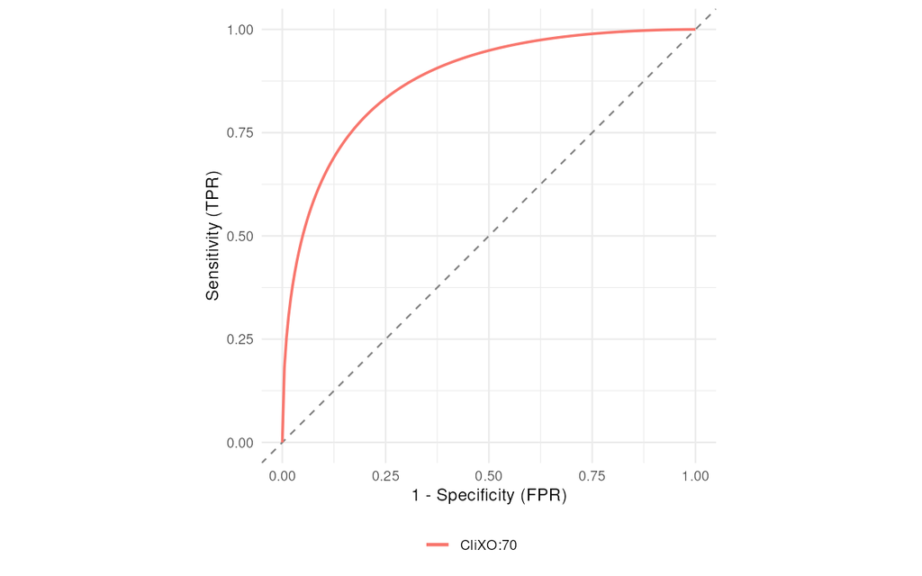

**Figure 10.** ROC curves for ontologies passing C1–C4 — LOPE — HELLP syndrome (T3) (Fig 3C, cx).

Table 11. AUROC, AUPRC, and calibration — LOPE — HELLP syndrome (T3) (Fig 3C, cx).

| Ontology | AUC-ROC (Dev) | AUC-ROC (Test) | AUC-PRC (Dev) | AUC-PRC (Test) | RMSE (Dev) | RMSE (Test) | C1 | C2 | C3 | C4 | Reported |
| --- | --- | --- | --- | --- | --- | --- | --- | --- | --- | --- | --- |
| root (SFXN3, GBE1, ASAH1, KLF3, GPT2, LEP, SH3PXD2A, PKM, GPX3, FLNB, IGF1, CEBPD, ERRFI1, CCDC127, PDE5A, IGSF8, CDO1, CCSAP, SYDE1, ERO1A, SLC25A4, TOR1B, FCN3, BCAR3, NFIL3, LDLR, EFNB1, VEGFA, GRH… | 0.695 (0.668, 0.722) | 0.502 (0.502, 0.503) | 0.611 | 0.516 | 0.419 (±0.0126) | 0.321 (±0.0030) | ✓\| | \| |  | ✓ |  |
| CliXO:78 (SFXN3, GBE1, ASAH1, KLF3, GPT2, LEP, SH3PXD2A, PKM, GPX3, FLNB, IGF1, CEBPD, ERRFI1, CCDC127, PDE5A, IGSF8, CDO1, CCSAP, SYDE1, ERO1A, SLC25A4, TOR1B, FCN3, BCAR3, NFIL3, LDLR, EFNB1, VEGFA,… | 0.776 (0.744, 0.808) | 0.452 (0.429, 0.475) | 0.103 | 0.431 | 0.441 (±0.0055) | 0.526 (±0.0006) | ✓\| | \| |  |  |  |
| ├── CliXO:53 (LDLR, SPON1) | 0.500 (0.500, 0.500) | 0.500 (0.500, 0.500) | 0.609 | 0.516 | 0.466 (±0.0275) | 0.181 (±0.0136) | ✓\| | ✓\| |  |  |  |
| ├── CliXO:70 (ASAH1, IGF1, PDE5A†, ZEB2, GMFB, APLN, AZIN1, NHLRC2, SPON1, IQGAP2, ZNF555) | 0.780 (0.757, 0.804) | 0.505 (0.504, 0.506) | 0.609 | 0.516 | 0.492 (±0.0137) | 0.674 (±0.0013) | ✓\| | ✓\| | ✓ | ✓ | CliXO:70 |
| │ ├── CliXO:65 (GMFB, AZIN1, NHLRC2, IQGAP2) | 0.500 (0.500, 0.500) | 0.500 (0.500, 0.500) | 0.609 | 0.516 | 0.466 (±0.0275) | 0.181 (±0.0136) | ✓\| | ✓\| |  |  |  |
| │ │ └── CliXO:55 (GMFB, AZIN1) | 0.500 (0.500, 0.500) | 0.500 (0.500, 0.500) | 0.609 | 0.516 | 0.466 (±0.0275) | 0.181 (±0.0136) | ✓\| | ✓\| |  |  |  |
| │ └── CliXO:68 (ASAH1, IGF1, PDE5A, ZEB2, APLN, AZIN1, NHLRC2, SPON1, IQGAP2, ZNF555) | 0.780 (0.757, 0.804) | 0.505 (0.504, 0.506) | 0.609 | 0.516 | 0.496 (±0.0140) | 0.681 (±0.0013) | ✓\| | ✓\| |  | ✓ | CliXO:70 |
| │ ├── CliXO:63 (PDE5A, AZIN1, NHLRC2, IQGAP2) | 0.780 (0.757, 0.804) | 0.505 (0.504, 0.506) | 0.609 | 0.516 | 0.493 (±0.0151) | 0.690 (±0.0013) | ✓\| | \| |  | ✓ | CliXO:70 |
| │ └── CliXO:67 (IGF1, PDE5A, ZEB2, SPON1, ZNF555) | 0.780 (0.757, 0.804) | 0.505 (0.504, 0.506) | 0.609 | 0.516 | 0.851 (±0.0140) | 0.954 (±0.0023) | ✓\| | ✓\| |  | ✓ |  |
| │ └── CliXO:62 (IGF1, ZEB2, SPON1) | 0.500 (0.500, 0.500) | 0.500 (0.500, 0.500) | 0.609 | 0.516 | 0.466 (±0.0275) | 0.181 (±0.0136) | ✓\| | ✓\| |  |  |  |
| │ └── CliXO:58 (IGF1, ZEB2) | 0.500 (0.500, 0.500) | 0.500 (0.500, 0.500) | 0.609 | 0.516 | 0.466 (±0.0275) | 0.181 (±0.0136) | ✓\| | ✓\| |  |  |  |
| └── CliXO:77 (SFXN3, GBE1, KLF3, GPT2, LEP, SH3PXD2A, PKM, GPX3, FLNB, CEBPD, ERRFI1, CCDC127, IGSF8, CDO1, CCSAP, SYDE1, ERO1A, SLC25A4, TOR1B, FCN3, BCAR3, NFIL3, LDLR, EFNB1, VEGFA, GRHL1, KRT19, Z… | 0.721 (0.677, 0.765) | 0.450 (0.426, 0.473) | 0.103 | 0.431 | 0.412 (±0.0136) | 0.452 (±0.0010) | ✓\| | \| |  |  | CliXO:71 |
| ├── CliXO:54 (GPX3, FCN3) | 0.500 (0.500, 0.500) | 0.500 (0.500, 0.500) | 0.609 | 0.516 | 0.466 (±0.0275) | 0.181 (±0.0136) | ✓\| | ✓\| |  |  |  |
| ├── CliXO:71 (GPT2, FLNB, CEBPD, ERRFI1, IGSF8, SLC25A4, TOR1B, LDLR, VEGFA, FAM43A†, CEBPA, PREP) | 0.189 (0.161, 0.217) | 0.450 (0.426, 0.473) | 0.088 | 0.431 | 0.454 (±0.0262) | 0.182 (±0.0117) | ✓\| | ✓\| | ✓ |  | CliXO:71 |
| │ └── CliXO:69 (GPT2, FLNB, CEBPD, ERRFI1, IGSF8, SLC25A4, TOR1B, LDLR, FAM43A, PREP) | 0.189 (0.161, 0.217) | 0.450 (0.426, 0.473) | 0.190 | 0.445 | 0.786 (±0.0125) | 0.880 (±0.0021) | ✓\| | ✓\| |  |  |  |
| │ └── CliXO:56 (LDLR, PREP) | 0.500 (0.500, 0.500) | 0.500 (0.500, 0.500) | 0.609 | 0.516 | 0.466 (±0.0275) | 0.181 (±0.0136) | ✓\| | ✓\| |  |  |  |
| └── CliXO:76 (SFXN3, GBE1, KLF3, GPT2, LEP, SH3PXD2A, PKM, GPX3, FLNB, CEBPD, ERRFI1, CCDC127, IGSF8, CDO1, CCSAP, SYDE1, ERO1A, TOR1B, BCAR3, NFIL3, EFNB1, VEGFA, GRHL1, KRT19, ZMYND8, FAM43A, GPR146… | 0.514 (0.478, 0.551) | 0.450 (0.426, 0.473) | 0.103 | 0.431 | 0.420 (±0.0174) | 0.416 (±0.0016) | ✓\| | ✓\| |  |  | CliXO:71 |
| ├── CliXO:66 (GPX3, CEBPD, VEGFA, GPR146, P4HA1) | 0.500 (0.500, 0.500) | 0.500 (0.500, 0.500) | 0.609 | 0.516 | 0.466 (±0.0275) | 0.181 (±0.0136) | ✓\| | ✓\| |  |  |  |
| │ └── CliXO:57 (GPX3, VEGFA) | 0.500 (0.500, 0.500) | 0.500 (0.500, 0.500) | 0.609 | 0.516 | 0.466 (±0.0275) | 0.181 (±0.0136) | ✓\| | ✓\| |  |  |  |
| └── CliXO:75 (SFXN3, GBE1, KLF3, GPT2, LEP, SH3PXD2A, PKM, FLNB, ERRFI1, CCDC127, CDO1, CCSAP, SYDE1, ERO1A, BCAR3, NFIL3, EFNB1, GRHL1, KRT19, ZMYND8, FAM43A, GPR146, NECTIN4, PIK3R1, SPAG4, BHLHE40,… | 0.511 (0.474, 0.547) | 0.550 (0.527, 0.574) | 0.377 | 0.080 | 0.691 (±0.0103) | 0.731 (±0.0016) | ✓\| | ✓\| |  |  |  |
| ├── CliXO:60 (NFIL3, BHLHE40, ANKRD37) | 0.500 (0.500, 0.500) | 0.500 (0.500, 0.500) | 0.609 | 0.516 | 0.466 (±0.0275) | 0.181 (±0.0136) | ✓\| | ✓\| |  |  |  |
| │ └── CliXO:59 (BHLHE40, ANKRD37) | 0.500 (0.500, 0.500) | 0.500 (0.500, 0.500) | 0.609 | 0.516 | 0.466 (±0.0275) | 0.181 (±0.0136) | ✓\| | ✓\| |  |  |  |
| └── CliXO:74 (SFXN3, GBE1, KLF3, GPT2, LEP, SH3PXD2A, PKM, FLNB, ERRFI1, CDO1, CCSAP, SYDE1, ERO1A, BCAR3, EFNB1, GRHL1, KRT19, ZMYND8, GPR146, NECTIN4, PIK3R1, SPAG4, BHLHE40, CORO2A, ANKRD37, P4HA1,… | 0.500 (0.500, 0.500) | 0.500 (0.500, 0.500) | 0.609 | 0.516 | 0.466 (±0.0275) | 0.181 (±0.0136) | ✓\| | ✓\| |  |  |  |
| └── CliXO:73 (SFXN3, KLF3, GPT2, LEP, SH3PXD2A, PKM, FLNB, ERRFI1, CCSAP, SYDE1, ERO1A, BCAR3, EFNB1, GRHL1, KRT19, GPR146, NECTIN4, SPAG4, BHLHE40, CORO2A, ANKRD37, P4HA1, PLIN2) | 0.500 (0.500, 0.500) | 0.500 (0.500, 0.500) | 0.609 | 0.516 | 0.466 (±0.0275) | 0.181 (±0.0136) | ✓\| | ✓\| |  |  |  |
| │ └── CliXO:59 (BHLHE40, ANKRD37) | 0.500 (0.500, 0.500) | 0.500 (0.500, 0.500) | 0.609 | 0.516 | 0.466 (±0.0275) | 0.181 (±0.0136) | ✓\| | ✓\| |  |  |  |
| ├── CliXO:64 (SFXN3, KLF3, NECTIN4, BHLHE40) | 0.500 (0.500, 0.500) | 0.500 (0.500, 0.500) | 0.609 | 0.516 | 0.466 (±0.0275) | 0.181 (±0.0136) | ✓\| | ✓\| |  |  |  |
| └── CliXO:72 (SFXN3, GPT2, LEP, SH3PXD2A, FLNB, CCSAP, SYDE1, ERO1A, KRT19, GPR146, NECTIN4, SPAG4, BHLHE40, CORO2A, P4HA1, PLIN2) | 0.500 (0.500, 0.500) | 0.500 (0.500, 0.500) | 0.609 | 0.516 | 0.466 (±0.0275) | 0.181 (±0.0136) | ✓\| | ✓\| |  |  |  |
| ├── CliXO:52 (ERO1A, P4HA1) | 0.500 (0.500, 0.500) | 0.500 (0.500, 0.500) | 0.609 | 0.516 | 0.466 (±0.0275) | 0.181 (±0.0136) | ✓\| | ✓\| |  |  |  |
| └── CliXO:61 (SFXN3, ERO1A, NECTIN4) | 0.500 (0.500, 0.500) | 0.500 (0.500, 0.500) | 0.609 | 0.516 | 0.466 (±0.0275) | 0.181 (±0.0136) | ✓\| | ✓\| |  |  |  |

**Reported column:** The ontology from the manuscript (Tables 1–2) to which this row’s eligible genes belong. An ontology is reported if it passes all three criteria (C1, C2, C3) and its eligible gene set is not a strict subset of another passing ontology’s gene set. Rows are empty when the ontology has no eligible genes or does not pass all three criteria.

# EOPE — Late-secretory endometrium (Fig 4A, cx)

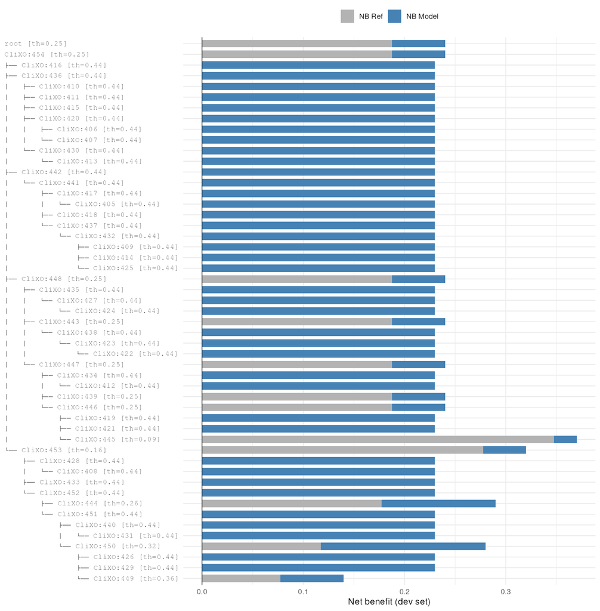

**Figure 12.** Net benefit of model vs. reference at selected thresholds — EOPE — Late-secretory endometrium (Fig 4A, cx).

Table 13. Confusion matrices — EOPE — Late-secretory endometrium (Fig 4A, cx).

| Ontology | PPV/TPR (Dev) | PPV/TPR (Test) | NPV/TNR (Dev) | NPV/TNR (Test) | C1 | C2 | C3 | C4 | Reported |
| --- | --- | --- | --- | --- | --- | --- | --- | --- | --- |
| root (ABCA1, ANKRD13A, ZFAND5, PANX1, RASEF, LAPTM5, RNF11, ACKR2, TBXAS1, ETS2, ARRDC3, BHLHE40, MTMR6, ARHGEF12, STRN3, ELF4, RAPH1, ENG, EPS8L2, RGS16, GRHL1, MBD2, OXSR1, CTSA, NCEH1, VEGFA, AKAP1… | 43.1% (40.7, 45.4) / 100.0% (100.0, 100.0) | 0.8% (0.7, 1.0) / — | — / 0.0% (0.0, 0.0) | — / 0.0% (0.0, 0.0) | \| | \| |  |  |  |
| CliXO:454 (ABCA1, ANKRD13A, ZFAND5, PANX1, RASEF, LAPTM5, RNF11, ACKR2, TBXAS1, ETS2, ARRDC3, BHLHE40, MTMR6, ARHGEF12, STRN3, ELF4, RAPH1, ENG, EPS8L2, RGS16, GRHL1, MBD2, OXSR1, CTSA, NCEH1, VEGFA, … | 43.1% (40.7, 45.4) / 100.0% (100.0, 100.0) | 0.8% (0.7, 1.0) / — | — / 0.0% (0.0, 0.0) | — / 0.0% (0.0, 0.0) | \| | \| |  |  |  |
| ├── CliXO:416 (KPNA1, NUCB2, ST6GALNAC1) | 72.0% (68.4, 75.7) / 76.7% (73.8, 79.6) | 0.8% (0.7, 1.0) / — | 81.7% (79.8, 83.5) / 77.3% (74.3, 80.4) | — / 0.0% (0.0, 0.0) | \| | \| |  |  |  |
| ├── CliXO:436 (CSF2RB, FAM43A, SLC38A6, PGK1, VDR, ANXA1, HEY1, LYPD3, CASD1, QPCT, COQ2, ARHGAP28, SPON1, BRCA1, CHEK1, TMEM106B, CDO1, HLF, SH3BGRL, CLIC3, WFS1, SESN3, PIK3R1, FGF13, RBM26, HEXB, S… | 72.0% (68.4, 75.7) / 76.7% (73.8, 79.6) | 0.8% (0.7, 1.0) / — | 81.7% (79.8, 83.5) / 77.3% (74.3, 80.4) | — / 0.0% (0.0, 0.0) | \| | \| |  |  |  |
| │ ├── CliXO:410 (HEY1, LYPD3) | 72.0% (68.4, 75.7) / 76.7% (73.8, 79.6) | 0.8% (0.7, 1.0) / — | 81.7% (79.8, 83.5) / 77.3% (74.3, 80.4) | — / 0.0% (0.0, 0.0) | \| | \| |  |  |  |
| │ ├── CliXO:411 (ARHGAP28, SESN3) | 72.0% (68.4, 75.7) / 76.7% (73.8, 79.6) | 0.8% (0.7, 1.0) / — | 81.7% (79.8, 83.5) / 77.3% (74.3, 80.4) | — / 0.0% (0.0, 0.0) | \| | \| |  |  |  |
| │ ├── CliXO:415 (COQ2, SPON1, CHEK1) | 72.0% (68.4, 75.7) / 76.7% (73.8, 79.6) | 0.8% (0.7, 1.0) / — | 81.7% (79.8, 83.5) / 77.3% (74.3, 80.4) | — / 0.0% (0.0, 0.0) | \| | \| |  |  |  |
| │ ├── CliXO:420 (CSF2RB, FAM43A, SLC38A6, CASD1, QPCT, SH3BGRL, FGF13, IL33, CNN3, MICU3) | 72.0% (68.4, 75.7) / 76.7% (73.8, 79.6) | 0.8% (0.7, 1.0) / — | 81.7% (79.8, 83.5) / 77.3% (74.3, 80.4) | — / 0.0% (0.0, 0.0) | \| | \| |  |  |  |
| │ │ ├── CliXO:406 (SH3BGRL, FGF13) | 72.0% (68.4, 75.7) / 76.7% (73.8, 79.6) | 0.8% (0.7, 1.0) / — | 81.7% (79.8, 83.5) / 77.3% (74.3, 80.4) | — / 0.0% (0.0, 0.0) | \| | \| |  |  |  |
| │ │ └── CliXO:407 (FAM43A, QPCT) | 72.0% (68.4, 75.7) / 76.7% (73.8, 79.6) | 0.8% (0.7, 1.0) / — | 81.7% (79.8, 83.5) / 77.3% (74.3, 80.4) | — / 0.0% (0.0, 0.0) | \| | \| |  |  |  |
| │ └── CliXO:430 (FAM43A, SLC38A6, HEY1, CASD1, QPCT, SPON1, CHEK1, TMEM106B, SH3BGRL, CLIC3, SESN3, PIK3R1, FGF13, RBM26, SMARCA2, IGSF8, CCND1, MAD2L2, C4orf3, PJA1, IL33, CNN3, DDR2, FBLIM1, LHFPL2,… | 72.0% (68.4, 75.7) / 76.7% (73.8, 79.6) | 0.8% (0.7, 1.0) / — | 81.7% (79.8, 83.5) / 77.3% (74.3, 80.4) | — / 0.0% (0.0, 0.0) | \| | \| |  |  |  |
| │ └── CliXO:413 (LHFPL2, PKM) | 72.0% (68.4, 75.7) / 76.7% (73.8, 79.6) | 0.8% (0.7, 1.0) / — | 81.7% (79.8, 83.5) / 77.3% (74.3, 80.4) | — / 0.0% (0.0, 0.0) | \| | \| |  |  |  |
| ├── CliXO:442 (PANX1, RNF11, BHLHE40, MTMR6, STRN3, NCEH1, VEGFA, JUNB, SMIM3, CSF2RB, TSC22D1, GULP1, CDKN1B, MINPP1, MXD1, FAM43A, ZNF281, SLC38A6, TMEM176B, SNAPC1, SPTY2D1, HILPDA, NR4A3, MAP3K8, … | 72.0% (68.4, 75.7) / 76.7% (73.8, 79.6) | 0.8% (0.7, 1.0) / — | 81.7% (79.8, 83.5) / 77.3% (74.3, 80.4) | — / 0.0% (0.0, 0.0) | \| | \| |  |  |  |
| │ └── CliXO:441 (RNF11, BHLHE40, MTMR6, STRN3, NCEH1, VEGFA, JUNB, SMIM3, CSF2RB, TSC22D1, GULP1, CDKN1B, MINPP1, MXD1, FAM43A, ZNF281, SLC38A6, TMEM176B, SNAPC1, HILPDA, NR4A3, SYNJ2, PPL, LATS2, TRE… | 72.0% (68.4, 75.7) / 76.7% (73.8, 79.6) | 0.8% (0.7, 1.0) / — | 81.7% (79.8, 83.5) / 77.3% (74.3, 80.4) | — / 0.0% (0.0, 0.0) | \| | \| |  |  |  |
| │ ├── CliXO:417 (WDFY3, HNMT, ARHGAP28, RCBTB1, ELMO1, LPXN) | 72.0% (68.4, 75.7) / 76.7% (73.8, 79.6) | 0.8% (0.7, 1.0) / — | 81.7% (79.8, 83.5) / 77.3% (74.3, 80.4) | — / 0.0% (0.0, 0.0) | \| | \| |  |  |  |
| │ │ └── CliXO:405 (ARHGAP28, RCBTB1) | 72.0% (68.4, 75.7) / 76.7% (73.8, 79.6) | 0.8% (0.7, 1.0) / — | 81.7% (79.8, 83.5) / 77.3% (74.3, 80.4) | — / 0.0% (0.0, 0.0) | \| | \| |  |  |  |
| │ ├── CliXO:418 (PGK1, SPAG4, HEY1, LYPD3, BCAR3, SLCO4A1) | 72.0% (68.4, 75.7) / 76.7% (73.8, 79.6) | 0.8% (0.7, 1.0) / — | 81.7% (79.8, 83.5) / 77.3% (74.3, 80.4) | — / 0.0% (0.0, 0.0) | \| | \| |  |  |  |
| │ └── CliXO:437 (RNF11, MTMR6, STRN3, JUNB, SMIM3, CSF2RB, TSC22D1, GULP1, CDKN1B, MINPP1, MXD1, FAM43A, ZNF281, SLC38A6, HILPDA, NR4A3, SYNJ2, TREM1, PGK1, DUSP4, ANKRD37, VDR, ITGA5, SPAG4, ANXA1, H… | 72.0% (68.4, 75.7) / 76.7% (73.8, 79.6) | 0.8% (0.7, 1.0) / — | 81.7% (79.8, 83.5) / 77.3% (74.3, 80.4) | — / 0.0% (0.0, 0.0) | \| | \| |  |  |  |
| │ └── CliXO:432 (RNF11, MTMR6, STRN3, SMIM3, CSF2RB, TSC22D1, GULP1, MXD1, FAM43A, SLC38A6, HILPDA, SYNJ2, TREM1, PGK1, DUSP4, VDR, ITGA5, ANXA1, HEY1, LYPD3, WDSUB1, CASD1, QPCT, ARHGAP28, SH3BGRL, S… | 72.0% (68.4, 75.7) / 76.7% (73.8, 79.6) | 0.8% (0.7, 1.0) / — | 81.7% (79.8, 83.5) / 77.3% (74.3, 80.4) | — / 0.0% (0.0, 0.0) | \| | \| |  |  |  |
| │ ├── CliXO:409 (WDSUB1, MICU3) | 72.0% (68.4, 75.7) / 76.7% (73.8, 79.6) | 0.8% (0.7, 1.0) / — | 81.7% (79.8, 83.5) / 77.3% (74.3, 80.4) | — / 0.0% (0.0, 0.0) | \| | \| |  |  |  |
| │ ├── CliXO:414 (ITGA5, ANXA1) | 72.0% (68.4, 75.7) / 76.7% (73.8, 79.6) | 0.8% (0.7, 1.0) / — | 81.7% (79.8, 83.5) / 77.3% (74.3, 80.4) | — / 0.0% (0.0, 0.0) | \| | \| |  |  |  |
| │ └── CliXO:425 (STRN3, SMIM3, CSF2RB, FAM43A, SLC38A6, HILPDA, CASD1, QPCT, ARHGAP28, SH3BGRL, SESN3, FGF13, IL33, CNN3, MME, MICU3) | 72.0% (68.4, 75.7) / 76.7% (73.8, 79.6) | 0.8% (0.7, 1.0) / — | 81.7% (79.8, 83.5) / 77.3% (74.3, 80.4) | — / 0.0% (0.0, 0.0) | \| | \| |  |  |  |
| ├── CliXO:448 (IFIT1, MXRA5, FBXO9, SLC25A4, TMEM216, PPA1, POLR2H, ILF2, KDM1A, THRA, CASD1, FKBP4, THOP1, SUMO3, SH3PXD2A, ALDH1B1, DLX5, CIB2, COL1A2, GLA, HDAC1, MRI1, DCXR, QPCT, KIF17, LSM6, GNG… | 43.1% (40.7, 45.4) / 100.0% (100.0, 100.0) | 0.8% (0.7, 1.0) / — | — / 0.0% (0.0, 0.0) | — / 0.0% (0.0, 0.0) | \| | \| |  |  |  |
| │ ├── CliXO:435 (POLR2H, ILF2, CASD1, SUMO3, SH3PXD2A, ALDH1B1, QPCT, GPER1, AMD1, TOP2B, CTSV, FAM172A, TSPAN3, NRIP1, FGF13, HEXB, CNPY4, CCND1, MAD2L2, FZD1, C4orf3, PUS7, FBN2, PJA1, IL33, PALLD, … | 72.0% (68.4, 75.7) / 76.7% (73.8, 79.6) | 0.8% (0.7, 1.0) / — | 81.7% (79.8, 83.5) / 77.3% (74.3, 80.4) | — / 0.0% (0.0, 0.0) | \| | \| |  |  |  |
| │ │ └── CliXO:427 (QPCT, AMD1, TOP2B, FAM172A, NRIP1, HEXB, CNPY4, CCND1, MAD2L2, FZD1, C4orf3, PJA1, IL33, PALLD, CNN3, DDR2, FBLIM1, AMOTL2, LHFPL2, PDGFC, MME, INPP5F) | 72.0% (68.4, 75.7) / 76.7% (73.8, 79.6) | 0.8% (0.7, 1.0) / — | 81.7% (79.8, 83.5) / 77.3% (74.3, 80.4) | — / 0.0% (0.0, 0.0) | \| | \| |  |  |  |
| │ │ └── CliXO:424 (QPCT, NRIP1, HEXB, CCND1, MAD2L2, FZD1, C4orf3, PJA1, IL33, CNN3, DDR2, FBLIM1, AMOTL2, PDGFC, MME) | 72.0% (68.4, 75.7) / 76.7% (73.8, 79.6) | 0.8% (0.7, 1.0) / — | 81.7% (79.8, 83.5) / 77.3% (74.3, 80.4) | — / 0.0% (0.0, 0.0) | \| | \| |  |  |  |
| │ ├── CliXO:443 (IFIT1, CASD1, DCXR, ZNF512B, COQ2, CTSF, SPON1, BRCA1, CHEK1, TSPAN3, TMEM106B, CDO1, SULF2, HLF, SH3BGRL, CLIC3, HSPA2, WFS1, SESN3, PIK3R1, TBC1D5, FGF13, TYRO3, RBM26, TAF9B, SMARC… | 43.1% (40.7, 45.4) / 100.0% (100.0, 100.0) | 0.8% (0.7, 1.0) / — | — / 0.0% (0.0, 0.0) | — / 0.0% (0.0, 0.0) | \| | \| |  |  |  |
| │ │ └── CliXO:438 (CASD1, DCXR, COQ2, SPON1, BRCA1, CHEK1, TMEM106B, CDO1, SULF2, HLF, SH3BGRL, CLIC3, HSPA2, WFS1, SESN3, PIK3R1, FGF13, TYRO3, RBM26, TAF9B, SMARCA2, TRIM24, CLCN5, PCYOX1, DDX17, GE… | 72.0% (68.4, 75.7) / 76.7% (73.8, 79.6) | 0.8% (0.7, 1.0) / — | 81.7% (79.8, 83.5) / 77.3% (74.3, 80.4) | — / 0.0% (0.0, 0.0) | \| | \| |  |  |  |
| │ │ └── CliXO:423 (CASD1, TMEM106B, SH3BGRL, WFS1, SESN3, PIK3R1, FGF13, TYRO3, RBM26, SMARCA2, TRIM24, PCYOX1, PIP5K1B, ZFP3, PAM) | 72.0% (68.4, 75.7) / 76.7% (73.8, 79.6) | 0.8% (0.7, 1.0) / — | 81.7% (79.8, 83.5) / 77.3% (74.3, 80.4) | — / 0.0% (0.0, 0.0) | \| | \| |  |  |  |
| │ │ └── CliXO:422 (CASD1, TMEM106B, SH3BGRL, WFS1, SESN3, PIK3R1, TYRO3, RBM26, SMARCA2, TRIM24) | 72.0% (68.4, 75.7) / 76.7% (73.8, 79.6) | 0.8% (0.7, 1.0) / — | 81.7% (79.8, 83.5) / 77.3% (74.3, 80.4) | — / 0.0% (0.0, 0.0) | \| | \| |  |  |  |
| │ └── CliXO:447 (IFIT1, MXRA5, FBXO9, SLC25A4, TMEM216, PPA1, POLR2H, ILF2, KDM1A, THRA, CASD1, FKBP4, THOP1, SUMO3, SH3PXD2A, ALDH1B1, DLX5, CIB2, COL1A2, GLA, HDAC1, MRI1, DCXR, KIF17, LSM6, GNG7, G… | 43.1% (40.7, 45.4) / 100.0% (100.0, 100.0) | 0.8% (0.7, 1.0) / — | — / 0.0% (0.0, 0.0) | — / 0.0% (0.0, 0.0) | \| | \| |  |  |  |
| │ ├── CliXO:434 (GLA, GLE1, LIN7A, LRRC41, TNFAIP8L1, KIAA0232, ODF2, DNMT3A, MTPN, HSPA2, CDK20, OVGP1, DNASE2, SUV39H1, TTLL5, OAS3, HMGB3, PPM1M, ST6GALNAC1, SLC39A8, MOB3C, DDX17, PEBP1, TKFC, SRP… | 72.0% (68.4, 75.7) / 76.7% (73.8, 79.6) | 0.8% (0.7, 1.0) / — | 81.7% (79.8, 83.5) / 77.3% (74.3, 80.4) | — / 0.0% (0.0, 0.0) | \| | \| |  |  |  |
| │ │ └── CliXO:412 (PODXL, NIPAL3) | 72.0% (68.4, 75.7) / 76.7% (73.8, 79.6) | 0.8% (0.7, 1.0) / — | 81.7% (79.8, 83.5) / 77.3% (74.3, 80.4) | — / 0.0% (0.0, 0.0) | \| | \| |  |  |  |
| │ ├── CliXO:439 (MXRA5, FBXO9, POLR2H, ILF2, KDM1A, THOP1, SUMO3, SH3PXD2A, CIB2, COL1A2, HDAC1, KIF17, GNG7, GPER1, AMD1, COL6A1, COPZ2, TOP2B, CTSV, FAM172A, GRINA, KIAA0232, XPO4, HEXB, IGSF8, CNPY… | 43.1% (40.7, 45.4) / 100.0% (100.0, 100.0) | 0.8% (0.7, 1.0) / — | — / 0.0% (0.0, 0.0) | — / 0.0% (0.0, 0.0) | \| | \| |  |  |  |
| │ └── CliXO:446 (IFIT1, MXRA5, FBXO9, SLC25A4, TMEM216, PPA1, POLR2H, ILF2, KDM1A, THRA, CASD1, FKBP4, THOP1, SUMO3, SH3PXD2A, ALDH1B1, DLX5, CIB2, COL1A2, GLA, HDAC1, MRI1, DCXR, KIF17, LSM6, GNG7, G… | 43.1% (40.7, 45.4) / 100.0% (100.0, 100.0) | 0.8% (0.7, 1.0) / — | — / 0.0% (0.0, 0.0) | — / 0.0% (0.0, 0.0) | \| | \| |  |  |  |
| │ ├── CliXO:419 (CTSF, OVGP1, SLC39A8, RDX, CDC42BPA, NIPAL3, HMGCR, RPL15, GSTK1) | 72.0% (68.4, 75.7) / 76.7% (73.8, 79.6) | 0.8% (0.7, 1.0) / — | 81.7% (79.8, 83.5) / 77.3% (74.3, 80.4) | — / 0.0% (0.0, 0.0) | \| | \| |  |  |  |
| │ ├── CliXO:421 (FBXO9, SLC25A4, KIF17, LIN7A, LRRC41, GRINA, DNASE2, IGSF8, UNC119, PIP5KL1) | 72.0% (68.4, 75.7) / 76.7% (73.8, 79.6) | 0.8% (0.7, 1.0) / — | 81.7% (79.8, 83.5) / 77.3% (74.3, 80.4) | — / 0.0% (0.0, 0.0) | \| | \| |  |  |  |
| │ └── CliXO:445 (IFIT1, MXRA5, FBXO9, SLC25A4, TMEM216, PPA1, POLR2H, ILF2, KDM1A, FKBP4, THOP1, SUMO3, SH3PXD2A, ALDH1B1, CIB2, COL1A2, GLA, HDAC1, MRI1, DCXR, KIF17, LSM6, GNG7, GPER1, AMD1, GLE1, Z… | 43.1% (40.7, 45.4) / 100.0% (100.0, 100.0) | 0.8% (0.7, 1.0) / — | — / 0.0% (0.0, 0.0) | — / 0.0% (0.0, 0.0) | \| | \| |  |  |  |
| └── CliXO:453 (ABCA1, ANKRD13A, ZFAND5, PANX1, RASEF, LAPTM5, RNF11, ACKR2, TBXAS1, ETS2, ARRDC3, BHLHE40, MTMR6, ARHGEF12, STRN3, ELF4, RAPH1, ENG, EPS8L2, RGS16, GRHL1, MBD2, OXSR1, CTSA, NCEH1, VEG… | 43.1% (40.7, 45.4) / 100.0% (100.0, 100.0) | 0.8% (0.7, 1.0) / — | — / 0.0% (0.0, 0.0) | — / 0.0% (0.0, 0.0) | \| | \| |  |  |  |
| ├── CliXO:428 (ANKRD13A, RASEF, ACKR2, TBXAS1, RGS16, OXSR1, GALE, CORO2A, PPP2R5A, ZFYVE1, RBM47, OPTN, IGSF3, TANK, SPI1, TSPAN14, TRAK2, AMPD3, UBALD2, SLC17A5, ASAP2, ERO1A, CSF3R, CPD) | 72.0% (68.4, 75.7) / 76.7% (73.8, 79.6) | 0.8% (0.7, 1.0) / — | 81.7% (79.8, 83.5) / 77.3% (74.3, 80.4) | — / 0.0% (0.0, 0.0) | \| | \| |  |  |  |
| │ └── CliXO:408 (RBM47, IGSF3) | 72.0% (68.4, 75.7) / 76.7% (73.8, 79.6) | 0.8% (0.7, 1.0) / — | 81.7% (79.8, 83.5) / 77.3% (74.3, 80.4) | — / 0.0% (0.0, 0.0) | \| | \| |  |  |  |
| ├── CliXO:433 (VEGFA, ZNF281, SLC38A6, SNAPC1, HILPDA, SYNJ2, PPL, TREM1, PGK1, DUSP4, ANKRD37, VDR, ITGA5, TSPAN13, SPAG4, ANXA1, HEY1, LYPD3, SGMS2, SEMA4B, BCAR3, TP53BP2, MYO5A, AMPD3, USP3, COL17… | 72.0% (68.4, 75.7) / 76.7% (73.8, 79.6) | 0.8% (0.7, 1.0) / — | 81.7% (79.8, 83.5) / 77.3% (74.3, 80.4) | — / 0.0% (0.0, 0.0) | \| | \| |  |  |  |
| └── CliXO:452 (ABCA1, ANKRD13A, ZFAND5, PANX1, RASEF, LAPTM5, RNF11, ACKR2, TBXAS1, ETS2, ARRDC3, BHLHE40, MTMR6, ARHGEF12, STRN3, ELF4, RAPH1, ENG, EPS8L2, RGS16, GRHL1, MBD2, OXSR1, CTSA, NCEH1, VEG… | 72.0% (68.4, 75.7) / 76.7% (73.8, 79.6) | 0.8% (0.7, 1.0) / — | 81.7% (79.8, 83.5) / 77.3% (74.3, 80.4) | — / 0.0% (0.0, 0.0) | \| | \| |  |  |  |
| ├── CliXO:444 (PANX1, RNF11, ARRDC3, BHLHE40, MTMR6, STRN3, NCEH1, VEGFA, JUNB, MAFF, SMIM3, CSF2RB, TSC22D1, GULP1, CDKN1B, NEK7, MINPP1, MXD1, FAM43A, ZNF217, SLC2A1, ZNF281, SLC38A6, TMEM176B, SNAP… | 72.0% (68.4, 75.7) / 76.7% (73.8, 79.6) | 0.8% (0.7, 1.0) / — | 81.7% (79.8, 83.5) / 77.3% (74.3, 80.4) | — / 0.0% (0.0, 0.0) | \| | \| |  |  |  |
| └── CliXO:451 (ABCA1, ANKRD13A, ZFAND5, PANX1, RASEF, LAPTM5, RNF11, ACKR2, TBXAS1, ETS2, ARRDC3, BHLHE40, MTMR6, ARHGEF12, STRN3, ELF4, RAPH1, ENG, EPS8L2, RGS16, GRHL1, MBD2, OXSR1, CTSA, NCEH1, VEG… | 72.0% (68.4, 75.7) / 76.7% (73.8, 79.6) | 0.8% (0.7, 1.0) / — | 81.7% (79.8, 83.5) / 77.3% (74.3, 80.4) | — / 0.0% (0.0, 0.0) | \| | \| |  |  |  |
| ├── CliXO:440 (ABCA1, ZFAND5, PANX1, LAPTM5, ACKR2, ETS2, ARRDC3, ARHGEF12, RGS16, GRHL1, OXSR1, NCEH1, AKAP13, YPEL2, TES, MAFF, SH3BP5, LYN, TSC22D1, GADD45G, MXD1, ZNF217, CHIC2, SLC2A1, PIK3AP1, S… | 72.0% (68.4, 75.7) / 76.7% (73.8, 79.6) | 0.8% (0.7, 1.0) / — | 81.7% (79.8, 83.5) / 77.3% (74.3, 80.4) | — / 0.0% (0.0, 0.0) | \| | \| |  |  |  |
| │ └── CliXO:431 (ABCA1, ZFAND5, PANX1, ETS2, ARHGEF12, NCEH1, TES, SH3BP5, TSC22D1, SLC2A1, MAP3K8, RNF19A, HTRA1, LRRC8A, EAF1, MXI1, PLIN2, LPL, ST6GAL1, FLI1, GRAMD1A, SARAF, EPS15, PTBP3, ELL2, PR… | 72.0% (68.4, 75.7) / 76.7% (73.8, 79.6) | 0.8% (0.7, 1.0) / — | 81.7% (79.8, 83.5) / 77.3% (74.3, 80.4) | — / 0.0% (0.0, 0.0) | \| | \| |  |  | CliXO:449 |
| └── CliXO:450 (ABCA1, ANKRD13A, ZFAND5, PANX1, RASEF, LAPTM5, RNF11, ACKR2, TBXAS1, ETS2, ARRDC3, BHLHE40, MTMR6, ARHGEF12, STRN3, ELF4, RAPH1, ENG, EPS8L2, RGS16, GRHL1, MBD2, OXSR1, CTSA, NCEH1, VEG… | 66.1% (63.2, 69.0) / 83.9% (81.2, 86.6) | 0.8% (0.7, 1.0) / — | 84.9% (82.4, 87.4) / 67.6% (65.0, 70.2) | — / 0.0% (0.0, 0.0) | \| | \| |  |  |  |
| ├── CliXO:426 (CORO1A, STAT4, PREP, GNG4, RHOBTB3, ARHGDIB, SARAF, CYFIP2, MEF2A, EFHD1, SLC9A9, HPGDS, LY86, RCBTB1, MAOB, ELMO1, LPXN) | 72.0% (68.4, 75.7) / 76.7% (73.8, 79.6) | 0.8% (0.7, 1.0) / — | 81.7% (79.8, 83.5) / 77.3% (74.3, 80.4) | — / 0.0% (0.0, 0.0) | \| | \| |  |  |  |
| ├── CliXO:429 (ANKRD13A, RASEF, TBXAS1, RAPH1, ENG, RGS16, GRHL1, CTSA, OPTN, IGSF3, EPS8L1, SPI1, TSPAN14, AMPD3, PTBP3, COL17A1, SLC31A2, UBALD2, RNF24, SLC17A5, SLC16A3, ASAP2, MAP4K4, PLOD2, CASP4… | 72.0% (68.4, 75.7) / 76.7% (73.8, 79.6) | 0.8% (0.7, 1.0) / — | 81.7% (79.8, 83.5) / 77.3% (74.3, 80.4) | — / 0.0% (0.0, 0.0) | \| | \| |  |  | CliXO:449 |
| └── CliXO:449 (ABCA1, ANKRD13A, ZFAND5, PANX1, RASEF, LAPTM5, RNF11, ACKR2, TBXAS1, ETS2, ARRDC3, BHLHE40, MTMR6, ARHGEF12, STRN3, ELF4, RAPH1, ENG, EPS8L2, RGS16, GRHL1, MBD2, OXSR1, CTSA, NCEH1, VEG… | 46.2% (43.8, 48.6) / 93.8% (92.1, 95.4) | 0.9% (0.7, 1.1) / — | 77.1% (70.2, 83.9) / 17.2% (14.5, 19.9) | 100.0% (100.0, 100.0) / 6.5% (5.9, 7.2) | \|✓ | \|✓ | ✓ |  | CliXO:449 |

**Reported column:** The ontology from the manuscript (Tables 1–2) to which this row’s eligible genes belong. An ontology is reported if it passes all three criteria (C1, C2, C3) and its eligible gene set is not a strict subset of another passing ontology’s gene set. Rows are empty when the ontology has no eligible genes or does not pass all three criteria.